# Прогноз потребления в МО и раннее обнаружение шоков

Конкурс СберИндекса 2026, трек «Прогнозирование»

Команда: Timofey Usenko MISIS

Методологический отчёт. Код, конфигурации и инструкция по запуску находятся в репозитории (README.md). Все таблицы отчёта формируются скриптом `scripts/render_report.py` из файлов `results/*.csv`, поэтому числа в таблицах совпадают с результатами расчётов. Числа в тексте дополнительно сверены с этими файлами независимым пересчётом (раздел 7.4).

# Аннотация

**Задача.** Требуется прогнозировать среднедушевые безналичные расходы жителей муниципальных образований (МО) по шести категориям на 1, 3, 6 и 12 месяцев вперёд точнее базовой модели Prophet и как можно раньше обнаруживать шоки, то есть резкие структурные изменения расходов.

**Метод прогноза.** Финальная модель представляет собой ансамбль из 11 членов с равными весами в логарифмах: 9 вариантов предложенной модели STF (Seasonality Transfer Forecaster, перенос сезонности) и две foundation-модели, Chronos-2 и TimesFM 2.5. STF компенсирует короткую историю рядов, перенося сезонный профиль с групп похожих рядов и с национальных рядов СберИндекса. Foundation-модели получают ряд с удлинённым контекстом, построенным по национальному ряду СберИндекса.

**Результат прогноза.** Модель проверена на всех 12 096 полных рядах (2 016 МО × 6 категорий) в трёх режимах оценки. Она точнее Prophet на всех горизонтах во всех режимах, причём как Prophet с настройками по умолчанию, так и настроенного. В основном режиме финальная модель точнее Prophet во всех 24 ячейках «категория × горизонт».

| режим оценки | h = 1 | h = 3 | h = 6 | h = 12 |
| --- | --- | --- | --- | --- |
| скользящая точка прогноза (основной) | **-47 %** | **-31 %** | **-38 %** | **-45 %** |
| одна точка T = 2024-12 - h | -79 % | -70 % | -58 % | -45 % |
| целевые месяцы 2024-07…2024-12 | -57 % | -50 % | -35 % | -45 % |

В таблице приведено изменение MAE относительно Prophet по умолчанию. Все 12 различий значимы: 95 % доверительный интервал кластерного бутстрепа по МО не содержит нуля. При h = 12 во всех режимах используется одна и та же точка прогноза T = 2023-12. Подробности приведены в разделе 4.

**Проверка на данных 2025 года.** Прогноз на 2025 г., построенный по данным до декабря 2024 г., сопоставлен с фактическими национальными рядами СберИндекса за 2025 г. Прирост расходов по всем категориям предсказан с ошибкой -0,13 п.п. (прогноз 14,02 %, факт 14,15 %, раздел 4.7). По отдельным категориям ошибка больше, а для продовольствия и здоровья простой бенчмарк оказался точнее модели.

**Обнаружение шоков.** Я сравнил 14 вариантов детекторов при одинаковом бюджете тревог в четырёх проверках: полусинтетический эксперимент с местными шоками, такой же эксперимент с региональными шоками, реестр реальных событий 2024 г. и независимая разметка по новостям. Лучший средний ранг у BOCPD (байесовское онлайн-обнаружение точки изменения): 6 из 8 событий реестра против 3 у панельного детектора и наименьшая задержка (0,1 мес.). На синтетических местных шоках лучший результат у панельного детектора (F1 = 0,64), который сравнивает остаток МО с медианой категории в регионе. Шоки, общие для всего региона, он по построению не видит, их обнаруживает региональный уровень (полнота 0,77).

**Новости.** Из 356 тыс. сообщений четырёх Telegram-каналов (ТАСС, РИА Новости, Интерфакс, МЧС России) за 2022-2024 гг. словарный фильтр отбирает около трети, которые затем размечает локальная языковая модель Qwen2.5-7B. Модель определяет, описывает ли сообщение реальное происшествие, его тип и тяжесть, и выбирает МО только из справочника СберИндекса. На проверочной выборке из 200 сообщений место и тип одновременно верны у 91 % событий, выданных моделью, против 69 % у первой версии на правилах. Выигрыш обеспечивает в основном фильтр: модель отбрасывает 86 % сообщений, не описывающих событие, и при этом теряет 16 % верных событий. Новости помогают объяснить отдельные крупные шоки, но почти не предсказывают их заранее (ROC-AUC 0,56).

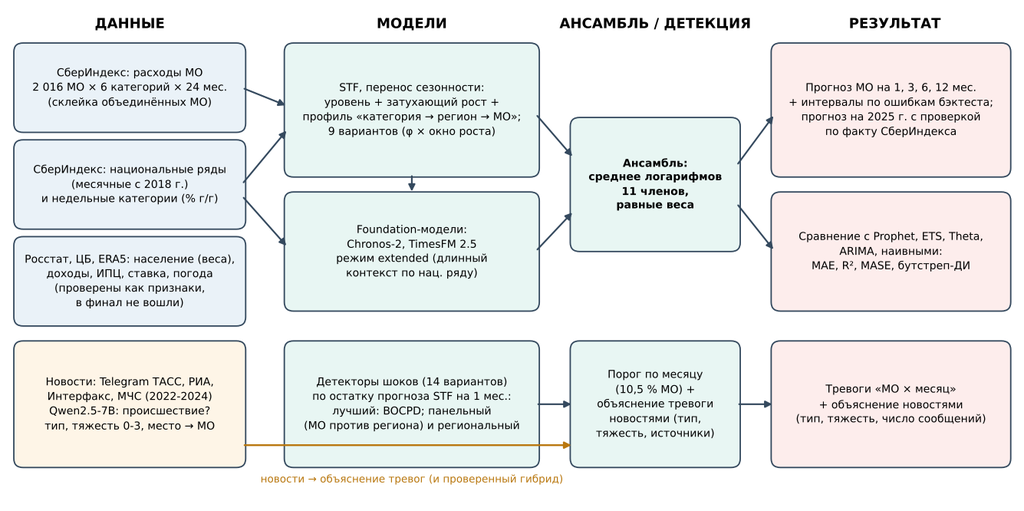

Архитектура решения

# 1. Постановка задачи

## 1.1 Объект прогноза

Единица прогноза: ряд «МО × категория», то есть средние безналичные расходы одного жителя МО за месяц в рублях. Рассматриваются шесть категорий: «Все категории», «Продовольствие», «Маркетплейсы», «Общественное питание», «Транспорт», «Здоровье». Данные охватывают 24 месяца, с января 2023 г. по декабрь 2024 г. Горизонты прогноза: 1, 3, 6 и 12 месяцев.

Организаторы оставили выбор категорий, МО и параметров участникам. Я прогнозирую все категории и все МО. Основная оценка ведётся на 12 096 полных рядах (24 месяца без пропусков). Неполные ряды тоже прогнозируются, но в сравнение не входят, так как у части из них нет даже 12 месяцев истории.

## 1.2 Определение шока

Шоком называется резкое изменение расходов, необычное для данного МО и не объяснимое сезонностью, общим трендом и общероссийскими событиями месяца. Формально шок соответствует большому остатку прогноза на один месяц после вычитания общего для категории эффекта месяца (раздел 5.1). Рассматриваются четыре формы шока: сдвиг уровня, временный провал, плавный сдвиг и разовый всплеск.

## 1.3 Основная трудность и идея решения

История рядов коротка. В первой точке прогноза (декабрь 2023 г.) у каждого ряда есть только 12 месяцев, то есть одно наблюдение на каждый месяц года. По одному году ни Prophet, ни ARIMA, ни ETS не могут надёжно оценить годовую сезонность. Поэтому центральная идея решения состоит в переносе сезонности из более длинных или более массовых источников: из похожих рядов той же категории и региона и из национальных рядов СберИндекса, которые начинаются в 2018 г.

## 1.4 Обоснование выбора подходов

Часть методов в решении не является стандартной для прогноза расходов, поэтому для каждого компонента ниже указано, какую проблему он решает и почему выбран именно он.

| компонент | почему выбран |
| --- | --- |
| STF, перенос сезонности | По 12-24 точкам сезонность отдельного ряда не оценивается. В панели тысячи рядов с похожей сезонностью внутри категории и региона, а национальные ряды СберИндекса содержат её с 2018 г. Иерархическое с… |
| затухающий рост | Текущий рост расходов, особенно у маркетплейсов, не сохраняется бесконечно. Затухание тренда (Gardner, McKenzie, 1985) является проверенным способом избежать линейной экстраполяции на длинных горизонт… |
| ансамбль с равными весами | При коротком периоде проверки оценённые веса ненадёжны, а простое среднее устойчивее (Smith, Wallis, 2009). |
| Chronos-2 и TimesFM 2.5 | Современные предобученные модели временных рядов работают без обучения на коротком ряду (zero-shot) и отвечают требованию конкурса об использовании фундаментальных моделей. Две модели разной архитекту… |
| AutoETS, AutoTheta, AutoARIMA | Стандартные классические эталоны с автоматическим подбором параметров. Theta выиграла соревнование M3 (Makridakis, Hibon, 2000). Они показывают, что выигрыш финальной модели не сводится к слабости одн… |
| панельный и региональный детекторы | Используют структуру данных: МО сравнивается с соседями по региону в том же месяце, что убирает общие сезонные и региональные эффекты. Региональный уровень закрывает слепую зону панельного детектора. |
| BOCPD | Байесовский онлайн-детектор оценивает вероятность смены режима в каждом месяце, работает в реальном времени без использования будущих данных и не требует заранее знать число точек изменения. |
| CUSUM, Page-Hinkley, PELT, BinSeg | Классические методы обнаружения точек изменения, включены как эталоны для сравнения. |
| Qwen2.5-7B-Instruct (AWQ) | Открытая модель с хорошим качеством на русском языке. В 4-битной квантизации помещается в одну GPU NVIDIA T4 и запускается локально через vLLM, без передачи данных во внешние сервисы. Ответ строго по … |
| выбор МО из справочника | Гарантирует, что каждая привязка новости существует в данных СберИндекса; согласование новостей с данными является отдельным критерием конкурса. |
| кластерный бутстреп по МО | Ошибки одного МО по категориям и месяцам связаны между собой, и обычный бутстреп занизил бы ширину доверительного интервала. |
| R² годового прироста и MASE | R² уровня почти всегда близок к 0,99 и не различает модели. R² прироста измеряет точность динамики, MASE позволяет сравнивать ряды разного масштаба. |

# 2. Данные

## 2.1 Источники

| источник | содержание | использование |
| --- | --- | --- |
| СберИндекс: расходы МО (`consumption.parquet`) | 303 126 строк: 2 190 МО, 77 регионов, 6 категорий, 2023-01…2024-12 | целевая переменная |
| СберИндекс: справочник МО (xlsx и полигоны gpkg) | версии МО, объединения, ОКТМО, полигоны | склейка объединённых МО, привязка новостей к `territory_id` |
| СберИндекс: национальные ряды consumer-spending | месячные расходы по России по 5 агрегатам, 2018-12…2026-08 | длинная сезонность, долгосрочный темп роста, удлинённый контекст для foundation-моделей, проверка прогноза 2025 г. |
| СберИндекс: недельное изменение трат | 46 категорий, % г/г, 2023-11…2026-09 | текущий рост маркетплейсов, здоровья и транспорта (у них нет месячного национального аналога), проверка 2025 г. |
| СберИндекс и ЦМИ: ключевая ставка, декомпозиция инфляции | месячные ряды | внешние признаки |
| СберИндекс: доступность рынков | индекс по МО | статический признак |
| Росстат | население МО на 01.01.2024 (по ОКТМО), доходы МО, бюллетени доходов и расходов регионов 2018-2024, ИПЦ регионов | веса агрегирования, внешние признаки |
| ERA5 (Copernicus; Hersbach и др., 2020) | температура, осадки, снег, ветер; 2 660 МО × 140 мес. | внешние признаки |
| Telegram: ТАСС, РИА Новости, Интерфакс, МЧС России | 356 тыс. сообщений, 2022-01…2024-12 | новости (раздел 6) |

Внешние признаки (ставка, инфляция, доходы, ИПЦ, погода, новости) проверены в модели поверх STF и в итоговый прогноз не вошли, поскольку не уменьшили ошибку (раздел 7.3).

## 2.2 Подготовка и контроль качества

- **Склейка объединённых МО.** В окно данных попали два объединения: Павловский Посад и Электрогорск (новый код 3014), г. Сасово и Сасовский район (3101). Ряды предшественников за 2023 г. объединены как средневзвешенное по населению, поскольку показатель среднедушевой и суммировать его нельзя. В результате получено 13 122 ряда, из них 12 096 полных.
- **Отсутствующие регионы.** В данных СберИндекса нет восьми регионов: Белгородской, Брянской, Курской, Воронежской и Ростовской областей, Краснодарского края, Республики Крым и Севастополя. Поэтому приграничные шоки 2022-2024 гг. в расходах не наблюдаются, хотя в новостях их много: на эти регионы приходится 41 % привязанных событий первой версии новостного модуля. Это ограничение учитывается во всех выводах о новостях.
- **Исправленные дефекты внешних данных.** (1) В выгрузке ERA5 в формате GRIB накопленные осадки и снег были сдвинуты на месяц назад. После исправления результат проверен: снега в летние месяцы нет, в Сочи максимум осадков приходится на зиму. (2) Первая выгрузка ИПЦ Росстата оказалась неполной и была загружена повторно. (3) Названия регионов в разных источниках различаются («Тюменская область без автономных округов»; «Республика Саха» при нечётком сравнении сопоставлялась с «Сахалинской областью»), для них составлен словарь соответствий. (4) Бюллетень численности населения на 2025 г. не опубликован, поэтому используются веса 2024 г.
- **Исключение утечки будущего.** Во всех расчётах модель в точке прогноза T использует только данные до T включительно. Национальный ряд обрезается по T, недельный ряд по последний день месяца T, новости отбираются по дате публикации, погодные аномалии считаются относительно климата 2015-2022 гг.

# 3. Схема оценки

## 3.1 Режимы оценки

Все модели оцениваются на одном и том же наборе из 12 096 полных рядов в трёх режимах.

1. **Скользящая точка прогноза (основной режим).** Модель строит прогноз из каждого месяца T = 2023-12, 2024-01, …, 2024-11 на месяц T + h, используя данные до T включительно. Для h = 1 получается 12 точек прогноза, для h = 3 десять, для h = 6 семь, для h = 12 одна (T = 2023-12). Всего 362 880 прогнозов на модель. Это наиболее статистически надёжный режим.
2. **Одна точка прогноза T = 2024-12 - h.** Классическая отложенная выборка из последних h месяцев. В таком режиме обычно проводят сравнение с Prophet.
3. **Целевые месяцы с июля по декабрь 2024 г.** Все прогнозы, попадающие во второе полугодие 2024 г. (далее H2).

## 3.2 Метрики

Обозначим через y фактическое значение и через ŷ прогноз. Усреднение ведётся по всем рядам и точкам прогноза при данном горизонте h.

- **MAE** = среднее |y - ŷ|, руб. на жителя в месяц. Основная метрика по условиям конкурса.
- **R² уровня.** Требуется условиями, однако в этой задаче почти всегда близок к 0,99: МО сильно различаются по уровню расходов, и даже прогноз «как в прошлом месяце» получает высокий R². Поэтому дополнительно считается **R² годового прироста**, то есть R² между фактическим и прогнозным приростом g = y<sub>t</sub> / y<sub>t-12</sub> - 1. Эта метрика показывает, предсказывает ли модель динамику, а не только уровень.
- **MAPE**, %.
- **MASE** (Hyndman, Koehler, 2006): отношение абсолютной ошибки к средней величине |y<sub>t</sub> - y<sub>t-1</sub>| ряда на обучающем отрезке. Значение меньше 1 означает, что модель точнее наивного прогноза «как в прошлом месяце» внутри выборки.
- **Доля рядов**, на которых модель точнее Prophet.
- **95 % доверительный интервал разности MAE**: кластерный бутстреп по МО, 1 000 повторов (Cameron и др., 2008). Ошибки одного МО по разным категориям и месяцам зависимы, поэтому при повторной выборке МО берутся целиком.

## 3.3 Фиксация гиперпараметров

Гиперпараметры зафиксированы в `configs/models.yaml` до оценки. Веса ансамбля равные и на тестовом периоде не подбирались. Решения, которые всё же принимались по результатам бэктеста, и связанные с ними оговорки перечислены в разделе 7.

# 4. Прогноз потребления

## 4.1 Сравниваемые модели

- **Prophet** (Taylor, Letham, 2018), базовая модель организаторов. Код организаторов не опубликован, поэтому рассчитаны два варианта. Prophet по умолчанию: `Prophet()` на месячных данных, отдельно для каждого ряда. Настроенный Prophet: мультипликативная сезонность, `yearly_seasonality=3`, `changepoint_prior_scale=0.01`. Оба варианта рассчитаны на всех рядах и во всех точках прогноза. Основное сравнение ведётся с Prophet по умолчанию, поскольку базовую модель обычно задают именно так. Настроенный Prophet точнее варианта по умолчанию в режиме одной точки и на целевых месяцах H2 при h от 1 до 6, но хуже в скользящем режиме и значительно хуже при h = 12. Финальная модель точнее обоих вариантов во всех режимах (раздел 4.4).
- **Наивные модели**: последнее значение; сезонная наивная модель (значение 12 месяцев назад); сезонная наивная модель с поправкой на годовой рост.
- **Классические статистические модели** из библиотеки statsforecast: AutoETS (Hyndman и др., 2008), AutoTheta (Assimakopoulos, Nikolopoulos, 2000), AutoARIMA (Hyndman, Khandakar, 2008). Каждая рассчитана в двух режимах: на исходном ряду с сезонностью 12 и на ряду, очищенном от сезонности STF.
- **Foundation-модели** без дообучения (zero-shot): Chronos-2 (Ansari и др., 2025) и TimesFM 2.5 (Das и др., 2024), каждая в трёх режимах подачи данных (раздел 4.3). Модель TiRex (NX-AI) также пробовалась, но её запуск завершился ошибкой при разборе выходных данных, и в сравнение она не вошла.
- **STF и ансамбль**, описанные ниже.

## 4.2 Модель STF

Прогноз STF строится в логарифмах как произведение трёх компонент:

> ŷ<sub>T+h</sub> = L<sub>T</sub> · G<sub>T,h</sub> · S<sub>m(T+h)</sub>,

где L<sub>T</sub> обозначает текущий уровень ряда, G<sub>T,h</sub> рост за h месяцев, S<sub>m</sub> сезонный множитель целевого месяца m.

1. **Уровень** L<sub>T</sub>: среднее двух последних значений ряда, очищенных от сезонности и приведённых к моменту T.
2. **Рост** G<sub>T,h</sub>. Годовой прирост категории оценивается как медиана прироста по всем МО панели за последние 1, 3 или 6 месяцев. Если у панели ещё нет года истории, используется национальный ряд СберИндекса. Для маркетплейсов, здоровья и транспорта, у которых нет месячного национального аналога, используется недельный ряд СберИндекса по соответствующей категории. Прирост региона учитывается частично: G<sub>регион</sub> = G<sub>категория</sub> · (G<sub>медиана региона</sub> / G<sub>категория</sub>)<sup>0,5</sup>. Текущий быстрый рост (например, у маркетплейсов от +50 до +70 % г/г) не может сохраняться бесконечно, поэтому месячный темп роста с каждым шагом стягивается к долгосрочному темпу национального ряда a, равному среднему приросту за 3 года до T: g<sub>h</sub> = a + (g - a)·φ<sup>h</sup>, где φ от 0,8 до 0,95 задаёт скорость затухания. Вместе с учётом регионального роста затухание уменьшило MAE при h = 6 и h = 12 на 51 и 43 руб. (раздел 7.2).
3. **Сезонность** S<sub>m</sub>: сезонный профиль ряда, сжатый к профилю группы по иерархии «категория, регион, МО». Медианный профиль категории по стране надёжен, так как опирается на тысячи рядов. Профиль региона входит с весом λ = 0,5, собственный профиль МО с весом λ = 0,3. Благодаря этому МО с одним годом истории получает устойчивую сезонность от похожих рядов и сохраняет собственные особенности, например более сильный летний пик в курортных МО.

**Ансамбль STF** состоит из 9 вариантов: φ ∈ {0,8; 0,9; 0,95} × окно оценки роста {1, 3, 6} мес. Прогнозы усредняются в логарифмах с равными весами. Короткое окно быстрее реагирует на изменения, длинное устойчивее к шуму. В бэктесте один из вариантов (φ = 0,8, окно 1 мес.: 310 / 417 / 443 / 521) оказался точнее среднего девяти (319 / 434 / 462 / 524), однако это можно установить только задним числом. Выбор варианта по тестовому периоду был бы подгонкой, а равные веса защищают от неудачного выбора. Это согласуется с известным эффектом комбинирования прогнозов: простое среднее обычно надёжнее оценённых весов (Smith, Wallis, 2009).

**Финальная модель** вычисляется как среднее логарифмов прогнозов 11 членов с равными весами: 9 вариантов STF, Chronos-2 extended и TimesFM 2.5 extended.

## 4.3 Foundation-модели и режимы подачи данных

Foundation-модели обучены на длинных рядах, и по ряду из 12-23 точек им трудно выделить сезонность. Я сравнил три режима подачи данных:

- **raw**: ряд подаётся без изменений, как обычно применяют foundation-модели;
- **stf_resid**: ряд, очищенный от сезонного профиля STF; модель прогнозирует только уровень и тренд, после чего сезонность возвращается;
- **extended**: к очищенному ряду МО добавляется синтетическая предыстория за 2019-2022 гг., равная уровню МО плюс динамика очищенного от сезонности национального ряда той же категории. Предыстория строится только по данным до точки прогноза.

| модель | режим | h=1 | h=3 | h=6 | h=12 |
| --- | --- | --- | --- | --- | --- |
| Chronos-2 | raw | 660 | 898 | 1 301 | 2 805 |
| Chronos-2 | stf_resid | 348 | 520 | 750 | 1 576 |
| Chronos-2 | extended | 332 | 478 | 677 | 960 |
| TimesFM 2.5 | raw | 636 | 856 | 1 241 | 2 672 |
| TimesFM 2.5 | stf_resid | 347 | 546 | 777 | 1 532 |
| TimesFM 2.5 | extended | 332 | 456 | 548 | 987 |
| ETS | raw | 654 | 803 | 1 002 | 1 802 |
| ETS | stf_resid | 347 | 496 | 644 | 1 111 |
| Theta | raw | 598 | 673 | 789 | 915 |
| Theta | stf_resid | 341 | 478 | 589 | 809 |
| ARIMA | raw | 684 | 890 | 1 156 | 2 150 |
| ARIMA | stf_resid | 336 | 486 | 632 | 1 011 |

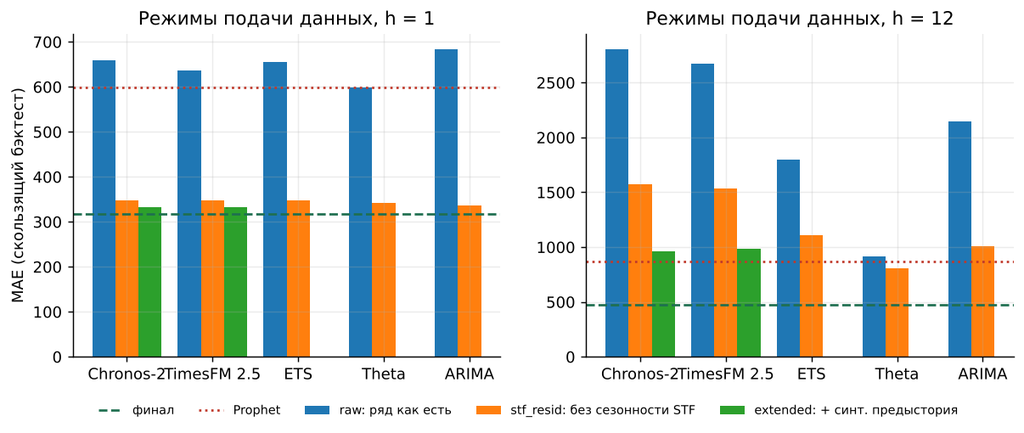

Режимы подачи данных

Подготовка данных снижает ошибку foundation-моделей в 2-3 раза: у Chronos-2 при h = 12 MAE уменьшается с 2 805 до 960 руб. Тем не менее по отдельности foundation-модели уступают STF, особенно на длинных горизонтах. В ансамбле они полезны: с ними MAE при h = 12 снижается с 524 до 476 руб., при h = 6 с 462 до 459 руб. Классические модели ведут себя аналогично: на очищенном от сезонности ряду они заметно точнее, чем на исходном, но в основном режиме уступают ансамблю STF на всех горизонтах (в отдельных срезах Theta на очищенном ряду бывает точнее, раздел 4.4).

**Оговорка о входных данных.** Классические модели и foundation-модели в режимах raw и stf_resid рассчитаны без недельных категорий СберИндекса, а STF и режим extended с ними. Недельные категории влияют только на точку прогноза 2023-12, в которой у панели ещё нет года истории для оценки роста, то есть в основном на h = 12. Проверка чувствительности, MAE при h = 1 / 3 / 6 / 12: Theta без них 341 / 478 / 589 / 809, с ними 335 / 463 / 570 / 715; ETS без них 347 / 496 / 644 / 1 111, с ними 341 / 484 / 627 / 1 177. Вывод о том, что классические модели уступают ансамблю STF, от этого не меняется.

## 4.4 Результаты

Таблицы построены на одном и том же наборе прогнозов: учитываются только те ряды, точки и горизонты, для которых есть прогнозы всех моделей. Строки упорядочены по MAE при h = 1.

**Скользящая точка прогноза (основной режим):**

| модель | MAE h=1 | MAE h=3 | MAE h=6 | MAE h=12 | R² г/г h=1 | R² г/г h=12 |
| --- | --- | --- | --- | --- | --- | --- |
| **Финал: 9 STF + Chronos-2 + TimesFM** | 317 | 429 | 459 | 476 | 0,81 | 0,27 |
| Ансамбль 9 STF | 319 | 434 | 462 | 524 | 0,81 | 0,31 |
| Chronos-2, extended | 332 | 478 | 677 | 960 | 0,80 | -0,59 |
| TimesFM 2.5, extended | 332 | 456 | 548 | 987 | 0,80 | -0,61 |
| STF (одна модель) | 336 | 465 | 528 | 772 | 0,80 | 0,14 |
| ARIMA, stf_resid | 336 | 486 | 632 | 1 011 | 0,78 | -0,83 |
| Theta, stf_resid | 341 | 478 | 589 | 809 | 0,79 | -0,30 |
| ETS, stf_resid | 347 | 496 | 644 | 1 111 | 0,78 | -0,41 |
| TimesFM 2.5, stf_resid | 347 | 546 | 777 | 1 532 | 0,76 | -0,62 |
| Chronos-2, stf_resid | 348 | 520 | 750 | 1 576 | 0,77 | -0,85 |
| Сезонный наивный × рост | 399 | 506 | 557 | 770 | 0,54 | 0,08 |
| Theta, raw | 598 | 673 | 789 | 915 | 0,69 | -0,79 |
| Prophet (по умолчанию) | 599 | 626 | 735 | 870 | 0,64 | -1,43 |
| TimesFM 2.5, raw | 636 | 856 | 1 241 | 2 672 | 0,70 | -1,53 |
| ETS, raw | 654 | 803 | 1 002 | 1 802 | 0,70 | -0,61 |
| Chronos-2, raw | 660 | 898 | 1 301 | 2 805 | 0,69 | -1,66 |
| Наивный (последнее значение) | 675 | 838 | 1 055 | 1 386 | 0,70 | -0,51 |
| ARIMA, raw | 684 | 890 | 1 156 | 2 150 | 0,65 | -1,92 |
| Prophet (настроенный) | 727 | 778 | 909 | 2 478 | 0,42 | -4,08 |
| Сезонный наивный | 1 266 | 1 329 | 1 312 | 1 386 | -0,44 | -0,51 |

**Одна точка прогноза T = 2024-12 - h:**

| модель | MAE h=1 | MAE h=3 | MAE h=6 | MAE h=12 | R² г/г h=1 | R² г/г h=12 |
| --- | --- | --- | --- | --- | --- | --- |
| Theta, stf_resid | 270 | 389 | 501 | 809 | 0,82 | -0,30 |
| **Финал: 9 STF + Chronos-2 + TimesFM** | 282 | 385 | 504 | 476 | 0,82 | 0,27 |
| Ансамбль 9 STF | 285 | 399 | 556 | 524 | 0,82 | 0,31 |
| STF (одна модель) | 287 | 427 | 687 | 772 | 0,81 | 0,14 |
| ARIMA, stf_resid | 292 | 425 | 684 | 1 011 | 0,78 | -0,83 |
| TimesFM 2.5, stf_resid | 292 | 427 | 692 | 1 532 | 0,79 | -0,62 |
| ETS, stf_resid | 295 | 438 | 650 | 1 111 | 0,79 | -0,41 |
| Chronos-2, stf_resid | 303 | 430 | 676 | 1 576 | 0,78 | -0,85 |
| TimesFM 2.5, extended | 311 | 380 | 490 | 987 | 0,79 | -0,61 |
| Chronos-2, extended | 318 | 368 | 569 | 960 | 0,77 | -0,59 |
| Сезонный наивный × рост | 351 | 468 | 728 | 770 | 0,52 | 0,08 |
| Prophet (настроенный) | 1 137 | 893 | 891 | 2 478 | 0,47 | -4,08 |
| Prophet (по умолчанию) | 1 360 | 1 300 | 1 210 | 870 | 0,33 | -1,43 |
| Сезонный наивный | 1 386 | 1 386 | 1 386 | 1 386 | -0,51 | -0,51 |
| Theta, raw | 1 410 | 1 369 | 1 321 | 915 | 0,50 | -0,79 |
| ETS, raw | 1 448 | 1 432 | 1 484 | 1 802 | 0,48 | -0,61 |
| TimesFM 2.5, raw | 1 458 | 1 723 | 2 000 | 2 672 | 0,54 | -1,53 |
| ARIMA, raw | 1 463 | 1 669 | 1 684 | 2 150 | 0,52 | -1,92 |
| Наивный (последнее значение) | 1 633 | 2 135 | 1 783 | 1 386 | 0,48 | -0,51 |
| Chronos-2, raw | 1 655 | 1 990 | 2 215 | 2 805 | 0,45 | -1,66 |

**Целевые месяцы с июля по декабрь 2024 г.:**

| модель | MAE h=1 | MAE h=3 | MAE h=6 | MAE h=12 | R² г/г h=1 | R² г/г h=12 |
| --- | --- | --- | --- | --- | --- | --- |
| Theta, stf_resid | 262 | 359 | 581 | 809 | 0,84 | -0,30 |
| **Финал: 9 STF + Chronos-2 + TimesFM** | 275 | 357 | 482 | 476 | 0,84 | 0,27 |
| Ансамбль 9 STF | 278 | 369 | 487 | 524 | 0,84 | 0,31 |
| TimesFM 2.5, stf_resid | 279 | 436 | 748 | 1 532 | 0,81 | -0,62 |
| ARIMA, stf_resid | 282 | 403 | 634 | 1 011 | 0,82 | -0,83 |
| Chronos-2, extended | 286 | 402 | 695 | 960 | 0,83 | -0,59 |
| ETS, stf_resid | 288 | 404 | 639 | 1 111 | 0,82 | -0,41 |
| STF (одна модель) | 290 | 396 | 562 | 772 | 0,83 | 0,14 |
| TimesFM 2.5, extended | 290 | 365 | 555 | 987 | 0,82 | -0,61 |
| Chronos-2, stf_resid | 293 | 414 | 728 | 1 576 | 0,81 | -0,85 |
| Сезонный наивный × рост | 352 | 438 | 585 | 770 | 0,56 | 0,08 |
| TimesFM 2.5, raw | 559 | 797 | 1 283 | 2 672 | 0,76 | -1,53 |
| Prophet (настроенный) | 560 | 575 | 653 | 2 478 | 0,64 | -4,08 |
| Chronos-2, raw | 613 | 877 | 1 361 | 2 805 | 0,74 | -1,66 |
| Theta, raw | 614 | 744 | 767 | 915 | 0,74 | -0,79 |
| Наивный (последнее значение) | 624 | 864 | 1 124 | 1 386 | 0,74 | -0,51 |
| ETS, raw | 634 | 807 | 1 036 | 1 802 | 0,73 | -0,61 |
| Prophet (по умолчанию) | 640 | 719 | 737 | 870 | 0,65 | -1,43 |
| ARIMA, raw | 644 | 862 | 1 094 | 2 150 | 0,74 | -1,92 |
| Сезонный наивный | 1 289 | 1 289 | 1 289 | 1 386 | -0,54 | -0,51 |

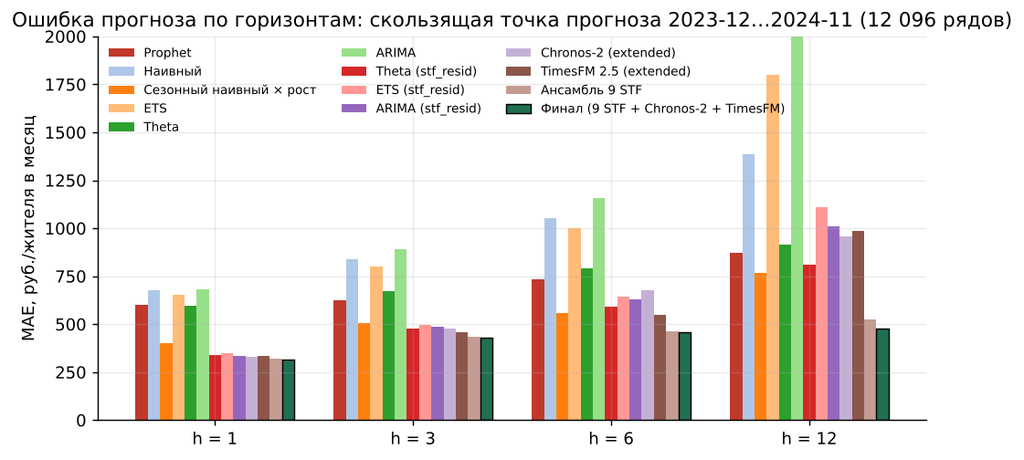

MAE по горизонтам

В основном режиме финальная модель лучшая на всех горизонтах. В более узких срезах отдельные модели её опережают:

- Theta на очищенном от сезонности ряду при h = 1: в режиме одной точки 270 против 282, на целевых месяцах H2 262 против 275; при h = 6 в режиме одной точки 501 против 504;
- Chronos-2 (368) и TimesFM 2.5 (380) при h = 3 и TimesFM 2.5 (490) при h = 6 в режиме одной точки.

Строка «STF (одна модель)» соответствует варианту без затухания роста, но с недельными категориями. Без затухания высокий текущий рост маркетплейсов (около +70 %) переносится на весь год вперёд, поэтому при h = 12 этот вариант хуже второго шага абляции (772 против 653). Это дополнительно подтверждает необходимость затухания.

**Сравнение финальной модели с Prophet по умолчанию**: разность MAE, 95 % доверительный интервал кластерного бутстрепа по МО и доля рядов, на которых финальная модель точнее.

| режим оценки | h | прогнозов | MAE Prophet | MAE финал | Δ MAE | 95 % ДИ Δ, руб. | рядов, где финал точнее |
| --- | --- | --- | --- | --- | --- | --- | --- |
| скользящий (все точки) | 1 | 145 152 | 599 | **317** | -47,0 % | -289 … -275 | 91 % |
| скользящий (все точки) | 3 | 120 960 | 626 | **429** | -31,5 % | -203 … -192 | 85 % |
| скользящий (все точки) | 6 | 84 672 | 735 | **459** | -37,5 % | -284 … -267 | 82 % |
| скользящий (все точки) | 12 | 12 096 | 870 | **476** | -45,2 % | -414 … -374 | 67 % |
| одна точка T = 2024-12 - h | 1 | 12 096 | 1 360 | **282** | -79,3 % | -1 101 … -1 055 | 79 % |
| одна точка T = 2024-12 - h | 3 | 12 096 | 1 300 | **385** | -70,4 % | -942 … -892 | 78 % |
| одна точка T = 2024-12 - h | 6 | 12 096 | 1 210 | **504** | -58,3 % | -729 … -681 | 71 % |
| одна точка T = 2024-12 - h | 12 | 12 096 | 870 | **476** | -45,2 % | -414 … -374 | 67 % |
| цели 2024-07…12 | 1 | 72 576 | 640 | **275** | -57,1 % | -374 … -358 | 91 % |
| цели 2024-07…12 | 3 | 72 576 | 719 | **357** | -50,3 % | -369 … -355 | 89 % |
| цели 2024-07…12 | 6 | 72 576 | 737 | **482** | -34,6 % | -262 … -247 | 80 % |
| цели 2024-07…12 | 12 | 12 096 | 870 | **476** | -45,2 % | -414 … -374 | 67 % |

**То же сравнение с настроенным Prophet.** Вывод не зависит от выбора варианта базовой модели.

| режим оценки | h | MAE Prophet (настроенный) | MAE финал | Δ MAE | 95 % ДИ Δ, руб. | рядов, где финал точнее |
| --- | --- | --- | --- | --- | --- | --- |
| скользящий (все точки) | 1 | 727 | **317** | -56,3 % | -415 … -403 | 83 % |
| скользящий (все точки) | 3 | 778 | **429** | -44,9 % | -357 … -342 | 79 % |
| скользящий (все точки) | 6 | 909 | **459** | -49,5 % | -460 … -441 | 81 % |
| скользящий (все точки) | 12 | 2 478 | **476** | -80,8 % | -2 046 … -1 962 | 83 % |
| одна точка T = 2024-12 - h | 1 | 1 137 | **282** | -75,2 % | -876 … -834 | 76 % |
| одна точка T = 2024-12 - h | 3 | 893 | **385** | -56,9 % | -529 … -489 | 62 % |
| одна точка T = 2024-12 - h | 6 | 891 | **504** | -43,4 % | -408 … -364 | 60 % |
| одна точка T = 2024-12 - h | 12 | 2 478 | **476** | -80,8 % | -2 046 … -1 962 | 83 % |
| цели 2024-07…12 | 1 | 560 | **275** | -51,0 % | -291 … -279 | 84 % |
| цели 2024-07…12 | 3 | 575 | **357** | -37,9 % | -225 … -211 | 72 % |
| цели 2024-07…12 | 6 | 653 | **482** | -26,2 % | -178 … -163 | 68 % |
| цели 2024-07…12 | 12 | 2 478 | **476** | -80,8 % | -2 046 … -1 962 | 83 % |

**Все метрики в скользящем режиме:**

| модель | метрика | h=1 | h=3 | h=6 | h=12 |
| --- | --- | --- | --- | --- | --- |
| Prophet (по умолчанию) | MAE, руб. | 599 | 626 | 735 | 870 |
| Prophet (по умолчанию) | R² уровня | 0,9895 | 0,9907 | 0,9878 | 0,9861 |
| Prophet (по умолчанию) | R² годового прироста | 0,64 | 0,52 | 0,16 | -1,43 |
| Prophet (по умолчанию) | MAPE, % | 9,7 | 11,1 | 12,8 | 15,9 |
| Prophet (по умолчанию) | MASE | 1,27 | 1,48 | 1,73 | 2,34 |
| Финал: 9 STF + Chronos-2 + TimesFM | MAE, руб. | 317 | 429 | 459 | 476 |
| Финал: 9 STF + Chronos-2 + TimesFM | R² уровня | 0,9974 | 0,9957 | 0,9952 | 0,9966 |
| Финал: 9 STF + Chronos-2 + TimesFM | R² годового прироста | 0,81 | 0,66 | 0,50 | 0,27 |
| Финал: 9 STF + Chronos-2 + TimesFM | MAPE, % | 6,6 | 8,2 | 8,6 | 8,8 |
| Финал: 9 STF + Chronos-2 + TimesFM | MASE | 0,80 | 1,07 | 1,15 | 1,38 |

Отставание Prophet объясняется тремя причинами. Во-первых, по одному году истории он не может оценить годовую сезонность. Например, в режиме одной точки при h = 1 он не видит декабрьского пика (MAE 1 360 против 282 у финальной модели). Во-вторых, Prophet экстраполирует линейный тренд, тогда как рост расходов на горизонте 12 месяцев замедляется. Это видно по R² годового прироста при h = 12: -1,43 у Prophet против +0,27 у финальной модели. В-третьих, Prophet не использует информацию из других рядов.

**По категориям** (скользящий режим, MAE Prophet и финальной модели) финальная модель точнее во всех 24 ячейках «категория × горизонт». Доверительные интервалы по отдельным ячейкам не строились, а при h = 12 используется одна точка прогноза. Поэтому малые разности (например, у маркетплейсов и продовольствия при h = 12) следует рассматривать как ориентир, а не как доказанное преимущество.

| категория | h=1 | h=3 | h=6 | h=12 |
| --- | --- | --- | --- | --- |
| Все категории | 1 805 → **947** (-48 %) | 1 755 → **1 250** (-29 %) | 2 159 → **1 276** (-41 %) | 2 901 → **1 061** (-63 %) |
| Здоровье | 119 → **90** (-24 %) | 146 → **109** (-26 %) | 126 → **105** (-16 %) | 244 → **113** (-53 %) |
| Маркетплейсы | 511 → **324** (-37 %) | 582 → **470** (-19 %) | 772 → **571** (-26 %) | 716 → **670** (-6 %) |
| Общественное питание | 142 → **83** (-41 %) | 182 → **118** (-35 %) | 210 → **119** (-43 %) | 206 → **98** (-53 %) |
| Продовольствие | 871 → **353** (-60 %) | 913 → **484** (-47 %) | 933 → **546** (-41 %) | 836 → **773** (-7 %) |
| Транспорт | 149 → **108** (-27 %) | 180 → **143** (-20 %) | 210 → **139** (-34 %) | 317 → **143** (-55 %) |

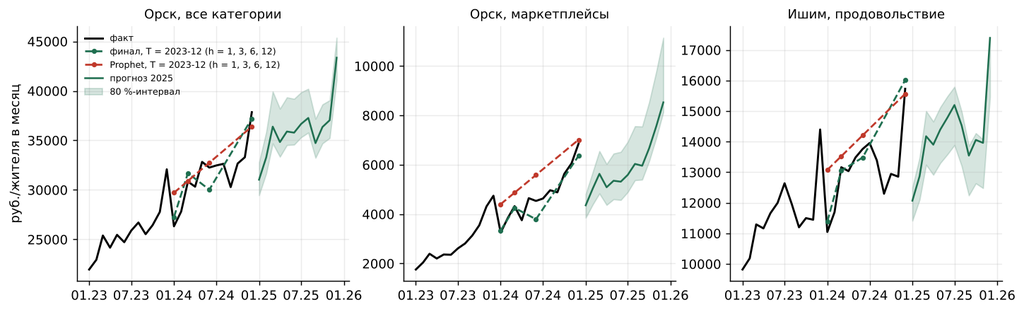

Примеры рядов

## 4.5 Абляция

Каждый шаг пересчитан текущей версией кода (`scripts/ablation.py`). Столбцы H2 относятся к целевым месяцам с июля по декабрь 2024 г.

| шаг | h=1 | h=3 | h=6 | h=12 | H2: h=1 | H2: h=3 | H2: h=6 | H2: h=12 |
| --- | --- | --- | --- | --- | --- | --- | --- | --- |
| 0. Prophet (по умолчанию) | 599 | 626 | 735 | 870 | 640 | 719 | 737 | 870 |
| 1. Наивный: последнее значение | 675 | 838 | 1 055 | 1 386 | 624 | 864 | 1 124 | 1 386 |
| 2. STF: уровень + рост + сезонность | 340 | 477 | 544 | 653 | 290 | 396 | 562 | 653 |
| 3. + ансамбль окон роста (3 STF) | 333 | 465 | 532 | 647 | 285 | 386 | 548 | 647 |
| 4. + затухающий рост, рег. рост (9 STF) | 324 | 446 | 481 | 604 | 278 | 369 | 487 | 604 |
| 5. + недельные категории СберИндекса (ens_stf9) | 319 | 434 | 462 | 524 | 278 | 369 | 487 | 524 |
| 6. + Chronos-2 и TimesFM (final) | 317 | 429 | 459 | 476 | 275 | 357 | 482 | 476 |

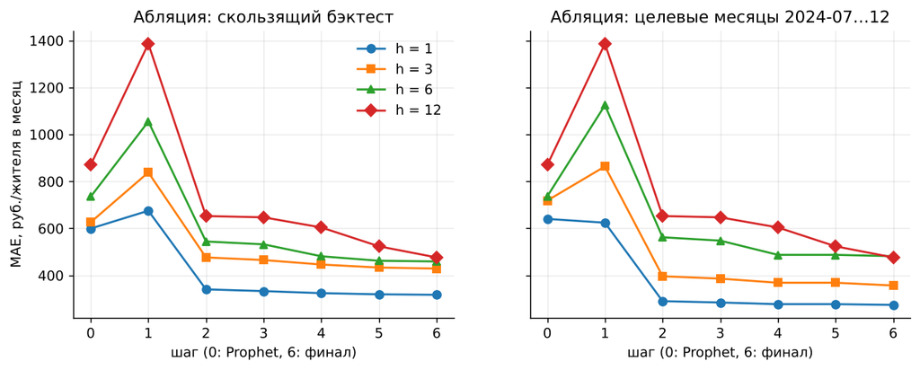

Абляция

## 4.6 Ошибка в месяцы шоков

Рассматриваются ряд-месяцы, в которых панельный детектор подаёт тревогу (2 % ряд-месяцев).

| модель | месяцы | h=1: MAE (MAPE) | h=3 | h=6 | h=12 |
| --- | --- | --- | --- | --- | --- |
| Prophet | обычный месяц | 597 (9,6 %) | 626 (11,0 %) | 735 (12,8 %) | 869 (15,8 %) |
| Prophet | месяц шока | 718 (16,6 %) | 649 (16,3 %) | 776 (17,1 %) | 939 (20,0 %) |
| Финал | обычный месяц | 313 (6,3 %) | 426 (8,1 %) | 457 (8,5 %) | 473 (8,7 %) |
| Финал | месяц шока | 554 (17,3 %) | 616 (16,4 %) | 703 (16,1 %) | 880 (21,6 %) |
| STF-ансамбль | обычный месяц | 315 (6,4 %) | 431 (8,3 %) | 460 (8,6 %) | 520 (9,5 %) |
| STF-ансамбль | месяц шока | 559 (17,4 %) | 616 (16,5 %) | 703 (16,2 %) | 932 (22,9 %) |

У финальной модели MAE в месяцы шоков в 1,4-1,9 раза выше, чем в обычные месяцы, а MAPE в 1,9-2,7 раза выше. В рублях она точнее Prophet и в месяцы шоков, однако по MAPE в эти месяцы немного уступает Prophet при h = 1, 3 и 12. Следует учитывать, что месяцы шоков выбраны детектором по остаткам STF, то есть по построению это месяцы наибольших ошибок STF, и сравнение смещено против моделей на основе STF. Вывод поэтому осторожный: в месяцы шоков преимущество модели прогноза пропадает, и для них необходим отдельный детектор (раздел 5).

## 4.7 Прогноз на 2025 год и его проверка

Финальная модель строит прогноз на 2025 г. из точки T = 2024-12 на горизонты h от 1 до 12. Национальный ряд для этого обрезан по декабрю 2024 г., недельные категории по 31.12.2024. Члены ансамбля: stf_d0.8_kg1, stf_d0.8_kg3, stf_d0.8_kg6, stf_d0.9_kg1, stf_d0.9_kg3, stf_d0.9_kg6, stf_d0.95_kg1, stf_d0.95_kg3, stf_d0.95_kg6, chronos2_extended, timesfm25_extended (11 членов). Foundation-модели рассчитаны тем же кодом, что и в бэктесте. Для контроля тот же запуск повторно рассчитал точку бэктеста T = 2023-12: все 52 488 прогнозов совпали с исходным бэктестом с нулевым расхождением (`results/fm_repro_check.csv`, `scripts/check_fm_repro.py`).

**Интервалы прогноза** строятся по фактическим ошибкам финальной модели в бэктесте: используются эмпирические квантили log(факт / прогноз) по горизонту и категории, промежуточные горизонты получаются линейной интерполяцией. Покрытие проверено вперёд по времени: квантили оцениваются по ранним точкам прогноза, а покрытие измеряется на поздних.

| h | точек калибровки | точек проверки | покрытие 80 %-интервала | покрытие 90 %-интервала |
| --- | --- | --- | --- | --- |
| 1 | 6 | 6 | 87,4 % | 94,8 % |
| 3 | 5 | 5 | 73,7 % | 83,5 % |
| 6 | 3 | 4 | 64,7 % | 77,3 % |

При h = 1 интервалы несколько шире необходимого (80 %-интервал накрывает 87 % фактических значений). При h от 3 до 6 они уже необходимого (при h = 6 покрытие 65 %), поскольку ошибки со временем растут. Для h от 7 до 12 интервалы опираются на одну точку прогноза и одну целевую дату, и проверить их покрытие нельзя. Для длинных горизонтов интервалы следует расширять.

**Проверка точности.** Фактических данных по МО за 2025 г. в открытом доступе нет: API СберИндекса отдаёт расходы МО только по декабрь 2024 г. Однако за 2025 г. доступны национальные ряды СберИндекса. Поэтому прогноз агрегируется по всем полным рядам с весами населения, и годовой прирост 2025 г. сравнивается с фактическим национальным. Точкой отсчёта служит разрыв между панелью и страной в 2024 г., поскольку панель безналичных расходов и национальная оценка измеряют не одно и то же. Бенчмарк предполагает, что прирост 2024 г. сохранится в 2025 г.

| категория | прогноз 2025, г/г | факт 2025 (СберИндекс), г/г | ошибка, п.п. | MAE по месяцам, п.п. | разрыв 2024 между панелью и страной, п.п. | бенчмарк «прирост 2024», MAE п.п. | источник факта |
| --- | --- | --- | --- | --- | --- | --- | --- |
| Все категории | 14,0 % | 14,2 % | -0,1 | 1,4 | 0,4 | 2,7 | consumer-spending (месячный) |
| Продовольствие | 8,6 % | 12,3 % | -3,7 | 4,3 | -2,8 | 1,6 | consumer-spending (месячный) |
| Маркетплейсы | 24,4 % | 36,9 % | -12,5 | 12,6 | 1,6 | 17,9 | недельные категории (среднее % г/г за месяц) |
| Общественное питание | 21,2 % | 49,5 % | не сопоставимо | - | -2,6 | - | consumer-spending (месячный); разрыв ряда: январь/декабрь 2025 = 1.131 против медианы 0.910 |
| Транспорт | 12,8 % | 9,0 % | 3,8 | 5,0 | -6,6 | 7,0 | недельные категории (среднее % г/г за месяц) |
| Здоровье | 10,2 % | 16,0 % | -5,8 | 5,8 | -4,5 | 4,2 | недельные категории (среднее % г/г за месяц) |

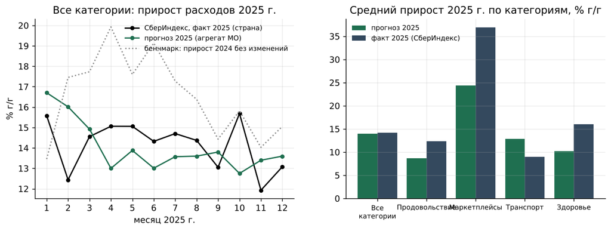

Прогноз 2025 против факта

- **Все категории.** Прирост расходов в 2025 г. предсказан с ошибкой -0,13 п.п. в среднем за год (прогноз 14,02 %, факт 14,15 %), MAE по месяцам 1,4 п.п. Бенчмарк в среднем ошибается на 2,4 п.п. (MAE по месяцам 2,7 п.п.). Модель верно предсказала замедление роста.
- **Продовольствие.** Ошибка -3,7 п.п. в основном объясняется устойчивым разрывом между панелью и страной, который наблюдался и в 2024 г. (-2,8 п.п.).
- **Маркетплейсы.** Рост замедлился примерно с 53 % в 2024 г. (по недельному ряду СберИндекса) до 37 % в 2025 г. Модель с затуханием дала 24 %: направление верное, но затухание оказалось сильнее фактического. Бенчмарк без затухания ошибся бы на +17 п.п.
- **Здоровье и транспорт.** Ошибка составила -6 и +4 п.п. Для здоровья бенчмарк точнее модели.
- **Общественное питание.** В национальном ряду СберИндекса в январе 2025 г. есть методологический разрыв, который скрипт находит автоматически: отношение января к декабрю равно 1,13 при обычном значении 0,91, прирост 2025 г. составляет около 50 %, а в 2026 г. возвращается к 15-19 %. Поэтому сравнение по этой категории некорректно и не проводится.

# 5. Обнаружение шоков

## 5.1 От остатка прогноза к тревоге

1. **Остаток прогноза на один месяц**: e<sub>t</sub> = log y<sub>t</sub> - log ŷ<sub>t|t-1</sub>, где ŷ<sub>t|t-1</sub> обозначает прогноз STF по данным до месяца t-1. Модель использует только прошлое, поэтому остаток измеряет неожиданность месяца t.
2. **Вычитание общего эффекта месяца.** Из остатка вычитается медиана остатков категории по всей стране в этом месяце. Без этого шага общероссийские события (праздники, календарные эффекты, изменение ставки) вызывали бы тревоги одновременно во всех МО. Отсутствие этого шага было главной ошибкой первоначальной постановки: без него CUSUM и PELT давали F1, близкий к нулю.
3. **Детектор** преобразует остатки в оценку необычности, а порог переводит оценку в тревогу. Все оценки вычисляются только по прошлому. Исключение составляют медианы по МО того же месяца, которые известны в момент принятия решения.

## 5.2 Детекторы

| детектор | принцип |
| --- | --- |
| panel (панельный) | остаток МО минус медиана остатков той же категории в регионе, делённый на робастный масштаб ряда; тревога, если МО отклоняется от соседей по региону |
| regional (региональный уровень) | медиана остатков категории в регионе в сравнении с историей самого региона; выявляет шок, общий для всего региона |
| panel_regional (двухуровневый) | тревога, если необычен МО относительно региона или регион относительно страны (максимум перцентильных рангов двух оценок) |
| conformal, conformal_raw | калиброванные квантили ошибки прогноза; вариант conformal_raw без вычитания общего эффекта месяца (абляция) |
| CUSUM, CUSUM с перезапуском, Page-Hinkley | накопленные отклонения (Page, 1954); вариант с перезапуском обнуляет статистику после превышения порога h = 4σ |
| BOCPD | байесовское онлайн-обнаружение точки изменения в собственной истории ряда (Adams, MacKay, 2007); оценка равна P(длина серии ≤ 1) |
| PELT, BinSeg | офлайн-сегментация (Killick и др., 2012; библиотека ruptures, Truong и др., 2020) на растущем окне без использования будущих данных |
| multivariate, panel_multivariate | одновременное отклонение нескольких категорий одного МО; во втором варианте среднее с панельной оценкой |
| panel_bocpd | максимум рангов панельного детектора и BOCPD |
| гибрид с новостями | оценка детектора × (1 + γ·[в МО в этом месяце есть происшествие тяжести не ниже 2]) |

Без гибрида с новостями получается 14 вариантов, все они рассчитываются на всех 12 096 полных рядах.

## 5.3 Полусинтетический эксперимент

Размеченных шоков в данных нет, поэтому в реальные ряды вставлялись шоки известного размера (от 5 до 30 % уровня), даты (2024 г.) и формы: сдвиг уровня, провал на 1 или 2 месяца, плавный сдвиг за 3 месяца и разовый всплеск. Рассмотрены два сценария:

- **местные шоки**: шок в отдельном ряду «МО × категория», в половине рядов;
- **региональные шоки**: один и тот же шок во всех МО региона в одной категории, в 30 % регионов (например, паводок, затрагивающий весь регион).

Порог каждого детектора подбирался на отдельной калибровочной половине рядов так, чтобы ложных тревог было 2 на 100 ряд-месяцев. Тем самым все детекторы сравниваются при одинаковой цене ложных тревог.

**Местные шоки:**

| детектор | F1 | полнота | точность | задержка, мес. | ложн. тревог / 100 | полнота: сдвиг | провал | рост-рампа | всплеск |
| --- | --- | --- | --- | --- | --- | --- | --- | --- | --- |
| panel_bocpd | 0,64 | 0,60 | 0,70 | 0,12 | 2,2 | 0,64 | 0,64 | 0,43 | 0,66 |
| panel | 0,64 | 0,59 | 0,69 | 0,12 | 2,2 | 0,64 | 0,63 | 0,43 | 0,65 |
| panel_multivariate | 0,62 | 0,56 | 0,69 | 0,14 | 2,2 | 0,60 | 0,60 | 0,42 | 0,62 |
| conformal | 0,55 | 0,48 | 0,63 | 0,19 | 2,0 | 0,51 | 0,55 | 0,31 | 0,56 |
| panel_regional | 0,55 | 0,48 | 0,63 | 0,13 | 2,2 | 0,53 | 0,54 | 0,31 | 0,54 |
| cusum_reset | 0,52 | 0,46 | 0,61 | 0,25 | 2,1 | 0,50 | 0,45 | 0,39 | 0,50 |
| bocpd | 0,47 | 0,43 | 0,52 | 0,09 | 2,0 | 0,48 | 0,51 | 0,21 | 0,49 |
| conformal_raw | 0,40 | 0,32 | 0,52 | 0,22 | 1,9 | 0,33 | 0,38 | 0,19 | 0,38 |
| binseg | 0,26 | 0,17 | 0,53 | 0,73 | 0,7 | 0,20 | 0,18 | 0,21 | 0,10 |
| pelt | 0,26 | 0,17 | 0,50 | 0,72 | 0,8 | 0,20 | 0,18 | 0,21 | 0,10 |
| multivariate | 0,19 | 0,14 | 0,29 | 0,29 | 2,1 | 0,18 | 0,15 | 0,08 | 0,17 |
| cusum | 0,19 | 0,14 | 0,27 | 0,52 | 1,9 | 0,21 | 0,15 | 0,11 | 0,11 |
| page_hinkley | 0,18 | 0,14 | 0,26 | 0,54 | 2,6 | 0,19 | 0,15 | 0,10 | 0,12 |
| regional | 0,07 | 0,05 | 0,12 | 0,36 | 2,2 | 0,05 | 0,05 | 0,04 | 0,06 |

**Региональные шоки** (сортировка по полноте). Точность здесь низкая у всех детекторов, поскольку шок есть лишь примерно у 4 % рядов при прежнем бюджете ложных тревог, поэтому основной показатель в этом сценарии полнота.

| детектор | F1 | полнота | точность | задержка, мес. | ложн. тревог / 100 | полнота: сдвиг | провал | рост-рампа | всплеск |
| --- | --- | --- | --- | --- | --- | --- | --- | --- | --- |
| regional | 0,25 | 0,77 | 0,15 | 0,04 | 2,0 | 1,00 | 1,00 | 0,18 | 0,70 |
| panel_regional | 0,21 | 0,68 | 0,12 | 0,16 | 2,2 | 0,92 | 1,00 | 0,33 | 0,37 |
| cusum_reset | 0,15 | 0,48 | 0,09 | 0,25 | 2,1 | 0,72 | 0,48 | 0,31 | 0,24 |
| conformal | 0,14 | 0,34 | 0,08 | 0,28 | 1,9 | 0,25 | 0,57 | 0,31 | 0,35 |
| bocpd | 0,07 | 0,25 | 0,04 | 0,16 | 2,1 | 0,27 | 0,26 | 0,12 | 0,31 |
| conformal_raw | 0,09 | 0,25 | 0,06 | 0,24 | 1,9 | 0,19 | 0,33 | 0,12 | 0,37 |
| multivariate | 0,07 | 0,17 | 0,04 | 0,02 | 2,0 | 0,22 | 0,21 | 0,08 | 0,14 |
| cusum | 0,07 | 0,17 | 0,05 | 0,55 | 2,5 | 0,34 | 0,14 | 0,06 | 0,00 |
| binseg | 0,09 | 0,15 | 0,07 | 0,39 | 0,8 | 0,23 | 0,02 | 0,06 | 0,18 |
| pelt | 0,09 | 0,15 | 0,06 | 0,39 | 0,8 | 0,23 | 0,02 | 0,06 | 0,18 |
| panel_multivariate | 0,03 | 0,10 | 0,02 | 0,35 | 2,2 | 0,12 | 0,10 | 0,08 | 0,08 |
| panel_bocpd | 0,02 | 0,06 | 0,01 | 0,62 | 2,2 | 0,03 | 0,10 | 0,08 | 0,07 |
| panel | 0,02 | 0,06 | 0,01 | 0,44 | 2,2 | 0,04 | 0,05 | 0,08 | 0,08 |
| page_hinkley | 0,01 | 0,03 | 0,01 | 0,75 | 2,4 | 0,05 | 0,02 | 0,04 | 0,00 |

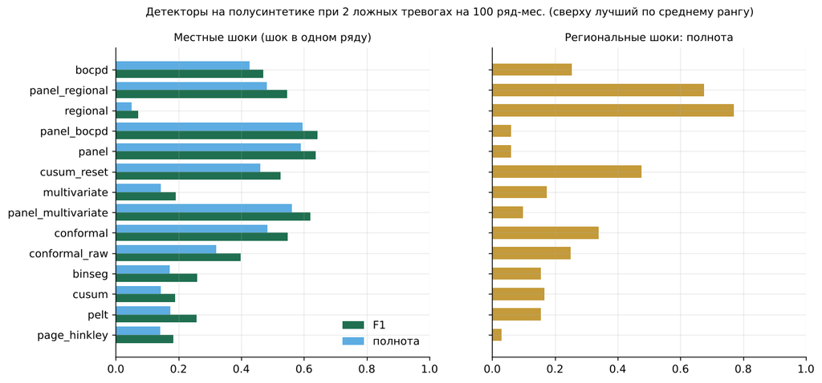

Детекторы

Результаты эксперимента:

- На местных шоках лучший панельный детектор (F1 0,64, задержка 0,12 мес.). Его комбинация с BOCPD (panel_bocpd) даёт такой же F1.
- На региональных шоках панельный детектор по построению не работает (полнота 0,06): шок сдвигает и сам МО, и медиану его региона. Такие шоки обнаруживает региональный уровень (полнота 0,77; для сдвига уровня и провала 100 %). Двухуровневый детектор устойчив в обоих сценариях: F1 0,55 на местных шоках и полнота 0,68 на региональных.
- Классический CUSUM без перезапуска после первого шока остаётся в состоянии тревоги на все последующие месяцы. Перезапуск повышает F1 с 0,19 до 0,52.
- PELT и BinSeg дают дискретную оценку, поэтому фактически работают при 0,7-0,8 ложной тревоги на 100 ряд-месяцев, а не при 2. Отчасти этим объясняется их низкая полнота.

## 5.4 Реальные события

**Схема сравнения.** Детекторы дают оценку для ряда, а событие относится к МО, поэтому оценка МО-месяца равна максимуму по категориям. Бюджет тревог одинаков для всех детекторов: 10,5 % МО в каждом месяце; столько даёт панельный детектор при 2 % ряд-месяцев. У детекторов с дискретной оценкой фактическая доля меньше (у PELT и BinSeg 0,8 %). Порог по срезу месяца применим в реальном времени и не позволяет детектору выигрывать за счёт месяцев, в которых у него много тревог. Например, PELT и BinSeg при общем пороге давали почти все тревоги в мае и октябре и поэтому попадали в апрельские паводки с запаздыванием.

**Реестр известных событий 2024 г.** включает 8 МО-месяцев, присутствующих в данных: паводки апреля и мая 2024 г. в Оренбургской, Курганской и Тюменской областях и теракт в «Крокус Сити Холле» (Красногорск). Попаданием считается тревога в месяц события или в следующий месяц.

| детектор | реестр | Орск 2024-04 | Новотроицк 2024-04 | г. Оренбург 2024-04 | Кувандык 2024-04 | г. Курган 2024-04 | Ишим 2024-04 | Абатский р-н 2024-05 | Красногорск 2024-03 |
| --- | --- | --- | --- | --- | --- | --- | --- | --- | --- |
| bocpd | 6 из 8 | ✓ | - | ✓ | ✓ | ✓ | ✓ | ✓ | - |
| bocpd+news_v2 (γ=0.5) | 6 из 8 | ✓ | - | ✓ | ✓ | ✓ | ✓ | ✓ | - |
| regional | 4 из 8 | ✓ | ✓ | ✓ | ✓ | - | - | - | - |
| panel+news_v2 (γ=0.5) | 4 из 8 | ✓ | - | - | ✓ | - | ✓ | ✓ | - |
| panel+news_v2 (γ=1.0) | 4 из 8 | ✓ | - | - | ✓ | - | ✓ | ✓ | - |
| panel | 3 из 8 | ✓ | - | - | ✓ | - | ✓ | - | - |
| multivariate | 3 из 8 | ✓ | - | - | ✓ | ✓ | - | - | - |
| panel_bocpd | 3 из 8 | ✓ | - | - | ✓ | - | ✓ | - | - |
| panel+news_v2 (γ=0.25) | 3 из 8 | ✓ | - | - | ✓ | - | ✓ | - | - |
| cusum_reset | 2 из 8 | ✓ | - | - | - | - | - | - | ✓ |
| panel_multivariate | 2 из 8 | ✓ | - | - | ✓ | - | - | - | - |
| pelt | 2 из 8 | ✓ | - | - | ✓ | - | - | - | - |
| binseg | 2 из 8 | ✓ | - | - | ✓ | - | - | - | - |
| panel_regional | 2 из 8 | ✓ | - | - | ✓ | - | - | - | - |
| conformal_raw | 0 из 8 | - | - | - | - | - | - | - | - |
| conformal | 0 из 8 | - | - | - | - | - | - | - | - |
| cusum | 0 из 8 | - | - | - | - | - | - | - | - |
| page_hinkley | 0 из 8 | - | - | - | - | - | - | - | - |

**Независимая разметка по новостям** (детекторы расходов новостей не используют): 49 МО-месяцев 2024 г., в которых было не меньше 10 местных новостей о бедствиях, безопасности и инфраструктуре, а число таких новостей превышало обычный уровень не менее чем в e² раз.

| детектор | доля МО-месяцев с тревогой | тревога в месяц события | lift | тревога в окне t-1…t+2 |
| --- | --- | --- | --- | --- |
| regional | 9,3 % | 24,5 % | 2,63 | 30,6 % |
| bocpd | 10,5 % | 22,4 % | 2,13 | 36,7 % |
| panel_regional | 9,9 % | 22,4 % | 2,28 | 42,9 % |
| multivariate | 10,5 % | 18,4 % | 1,75 | 34,7 % |
| panel | 10,5 % | 18,4 % | 1,75 | 36,7 % |
| panel_bocpd | 10,5 % | 18,4 % | 1,75 | 36,7 % |
| cusum | 10,5 % | 16,3 % | 1,55 | 20,4 % |
| panel_multivariate | 10,5 % | 16,3 % | 1,55 | 34,7 % |
| cusum_reset | 10,5 % | 16,3 % | 1,55 | 46,9 % |
| page_hinkley | 10,5 % | 14,3 % | 1,36 | 16,3 % |
| conformal | 10,5 % | 8,2 % | 0,78 | 16,3 % |
| conformal_raw | 10,5 % | 6,1 % | 0,58 | 10,2 % |
| pelt | 0,8 % | 2,0 % | 2,49 | 10,2 % |
| binseg | 0,8 % | 2,0 % | 2,65 | 10,2 % |

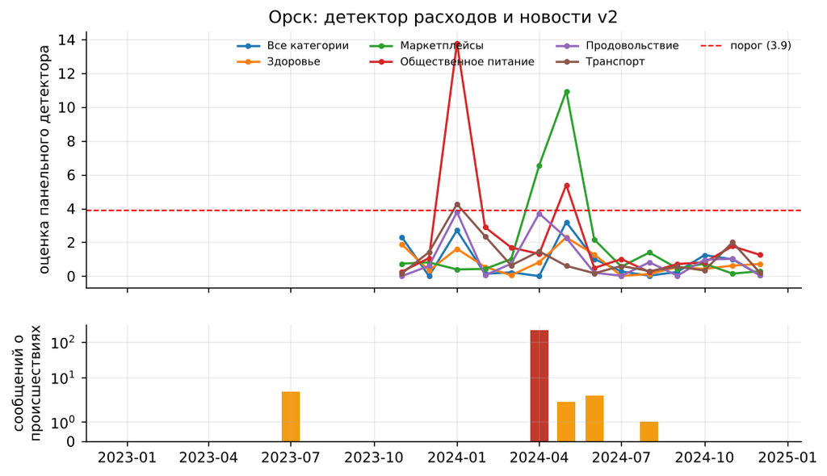

Орск

**Пример: Орск, апрель 2024 г.** (прорыв дамбы и паводок). Панельный детектор подаёт тревогу в апреле (оценка 6,5 при пороге 3,9) и в мае (11,0) по категории «Маркетплейсы». В апреле расходы на маркетплейсах снизились на 13 % к марту (годом ранее апрельское снижение составило 8 %, при этом сама категория за год выросла примерно на 70 %), а в мае восстановились на 24 %. Новостной модуль в том же месяце находит происшествие «паводок» тяжести 3: 192 сообщения в 4 каналах, режим ЧС, эвакуация и отключения коммунальных услуг.

**Различия между детекторами.** Паводок 2024 г. затронул сразу несколько соседних МО (Орск, Новотроицк, Оренбург, Кувандык; Курган и Ишим). Когда шок есть у многих МО региона, медиана региона тоже смещается, и панельный детектор видит его хуже. BOCPD анализирует собственную историю ряда (после вычитания общего эффекта страны) и такие частично региональные шоки обнаруживает: 6 из 8 событий реестра против 3 у панельного детектора. Теракт в «Крокус Сити Холле» почти не изменил среднедушевые расходы Красногорского округа, его замечает только CUSUM с перезапуском.

**Порог по месяцу.** При общем пороге тревоги панельного детектора распределены по месяцам неравномерно: в январе 2024 г. их 647 МО-месяцев, в остальные месяцы от 94 до 361. Сезонный профиль января оценён по одному году, а праздники сильнее всего сдвигают остаток. Порог по месяцу выравнивает поток до 208-226 тревог в месяц и сохраняет те же 3 из 8 событий реестра у панельного детектора (`results/cp_month_threshold.csv`). Поэтому все сравнения на реальных событиях выполнены с порогом по месяцу.

## 5.5 Сводное сравнение и выбор детектора

Используются четыре проверки: F1 на местных шоках, полнота на региональных шоках, реестр 2024 г. и новостная разметка (две последние с порогом по месяцу). Средний ранг по четырём проверкам:

| детектор | F1: местные шоки | задержка, мес. | полнота: региональные шоки | реестр 2024 | новости: тревога в месяц события | средний ранг (1-4) |
| --- | --- | --- | --- | --- | --- | --- |
| bocpd | 0,47 | 0,09 | 0,25 | 6 из 8 | 22,4 % | 3,88 |
| panel_regional | 0,55 | 0,13 | 0,68 | 2 из 8 | 22,4 % | 4,38 |
| regional | 0,07 | 0,36 | 0,77 | 4 из 8 | 24,5 % | 4,50 |
| panel_bocpd | 0,64 | 0,12 | 0,06 | 3 из 8 | 18,4 % | 5,62 |
| panel | 0,64 | 0,12 | 0,06 | 3 из 8 | 18,4 % | 5,88 |
| cusum_reset | 0,52 | 0,25 | 0,48 | 2 из 8 | 16,3 % | 6,25 |
| multivariate | 0,19 | 0,29 | 0,17 | 3 из 8 | 18,4 % | 6,75 |
| panel_multivariate | 0,62 | 0,14 | 0,10 | 2 из 8 | 16,3 % | 7,50 |
| conformal | 0,55 | 0,19 | 0,34 | 0 из 8 | 8,2 % | 7,88 |
| conformal_raw | 0,40 | 0,22 | 0,25 | 0 из 8 | 6,1 % | 9,62 |
| binseg | 0,26 | 0,73 | 0,15 | 2 из 8 | 2,0 % | 10,00 |
| cusum | 0,19 | 0,52 | 0,17 | 0 из 8 | 16,3 % | 10,12 |
| pelt | 0,26 | 0,72 | 0,15 | 2 из 8 | 2,0 % | 10,25 |
| page_hinkley | 0,18 | 0,54 | 0,03 | 0 из 8 | 14,3 % | 12,38 |

**Лучший детектор по сумме проверок BOCPD.** Он первый на реестре (6 из 8 событий), входит в число лучших на новостной разметке (22 % МО-месяцев с тревогой в месяц события, у регионального уровня 24,5 %), реагирует быстрее всех (задержка 0,1 мес.) и занимает среднее положение на синтетике (F1 0,47 на местных шоках). На синтетических местных шоках лучший панельный детектор (F1 0,64, как и его комбинация с BOCPD), а двухуровневый panel_regional даёт лучший компромисс на синтетике, так как устойчив и к местным, и к региональным шокам. Реальных событий мало (8 и 49), и различия между лучшими детекторами на них статистически не значимы. Синтетика содержит тысячи шоков, но только заданного вида.

**Рекомендуемая конфигурация мониторинга.** Основной канал: BOCPD с порогом по месяцу. Второй канал: двухуровневый детектор, который дополнительно указывает, местный это шок или региональный. Каждая тревога сопровождается новостным объяснением: тип, тяжесть, число сообщений, источники.

**Гибрид с новостями.** Множитель к оценке детектора при тяжёлом происшествии в МО (γ = 0,5) добавляет панельному детектору одно событие реестра (4 из 8 вместо 3, добавился Абатский район), а BOCPD не добавляет ни одного (6 из 8). Цена для панельного детектора: 6,6 % его тревог переходит на МО-месяцы с тяжёлыми происшествиями. Значение γ выбрано на том же реестре, а реестр состоит из резонансных событий с большим числом публикаций, поэтому результат следует считать наблюдением, а не доказанным эффектом.

**Тревоги, объяснимые новостями.** Из 2 541 тревоги панельного детектора уровня «МО × месяц» в 2024 г. у 10 в том же МО и месяце было крупное происшествие (тяжесть не ниже 2 и не меньше 5 сообщений). Среди них:

- Торопецкий округ, 09.2024: атака БПЛА, 21 сообщение;
- Звериноголовский округ и Ишим, 04.2024: паводок;
- Орск, 04.2024: паводок, 192 сообщения;
- Владикавказ, 12.2024: пожар, 19 сообщений;
- Печора, 05.2024: авария, 12 сообщений.

Остальные тревоги новостями не объясняются. Это ожидаемо: большинство шоков в расходах вызвано событиями, о которых федеральные каналы не сообщают. Поэтому новости служат объяснением для отдельных крупных шоков, а не для большинства тревог.

## 5.6 Раннее предупреждение

Чтобы проверить, предсказуемы ли шоки заранее, я обучил модель LightGBM, оценивающую вероятность шока в МО двумя способами: в месяце t+1 по данным на конец месяца t (прогноз) и в месяце t по новостям месяца t и расходам месяца t-1 (наукастинг). Шоком здесь считается тревога панельного детектора в любой категории МО, то есть местный шок. Обучение проводится на месяцах до мая 2024 г., проверка на месяцах с июня по ноябрь 2024 г.

| режим | новости | признаки | ROC-AUC | PR-AUC | lift топ-5 % |
| --- | --- | --- | --- | --- | --- |
| прогноз на t+1 | v1 | инерция (тревога и сила в t) | 0,628 | 0,118 | 3,03 |
| прогноз на t+1 | v1 | + соседи по региону | 0,609 | 0,120 | 2,89 |
| прогноз на t+1 | v1 | + погода | 0,592 | 0,100 | 2,72 |
| прогноз на t+1 | v1 | + новости | 0,571 | 0,084 | 2,23 |
| прогноз на t+1 | v1 | + новости + свойства МО | 0,585 | 0,084 | 2,15 |
| прогноз на t+1 | v1 | только новости | 0,545 | 0,069 | 1,43 |
| прогноз на t+1 | v2 | инерция (тревога и сила в t) | 0,628 | 0,118 | 3,03 |
| прогноз на t+1 | v2 | + соседи по региону | 0,609 | 0,120 | 2,89 |
| прогноз на t+1 | v2 | + погода | 0,592 | 0,100 | 2,72 |
| прогноз на t+1 | v2 | + новости | 0,613 | 0,101 | 2,35 |
| прогноз на t+1 | v2 | + новости + свойства МО | 0,638 | 0,101 | 2,43 |
| прогноз на t+1 | v2 | только новости | 0,559 | 0,070 | 1,46 |
| наукастинг t | v1 | инерция (тревога и сила в t) | 0,629 | 0,130 | 2,98 |
| наукастинг t | v1 | + соседи по региону | 0,632 | 0,130 | 3,01 |
| наукастинг t | v1 | + погода | 0,570 | 0,097 | 2,19 |
| наукастинг t | v1 | + новости | 0,524 | 0,079 | 1,66 |
| наукастинг t | v1 | + новости + свойства МО | 0,547 | 0,082 | 1,76 |
| наукастинг t | v1 | только новости | 0,525 | 0,070 | 1,23 |
| наукастинг t | v2 | инерция (тревога и сила в t) | 0,629 | 0,130 | 2,98 |
| наукастинг t | v2 | + соседи по региону | 0,632 | 0,130 | 3,01 |
| наукастинг t | v2 | + погода | 0,570 | 0,097 | 2,19 |
| наукастинг t | v2 | + новости | 0,602 | 0,106 | 2,32 |
| наукастинг t | v2 | + новости + свойства МО | 0,628 | 0,108 | 2,16 |
| наукастинг t | v2 | только новости | 0,559 | 0,079 | 1,53 |

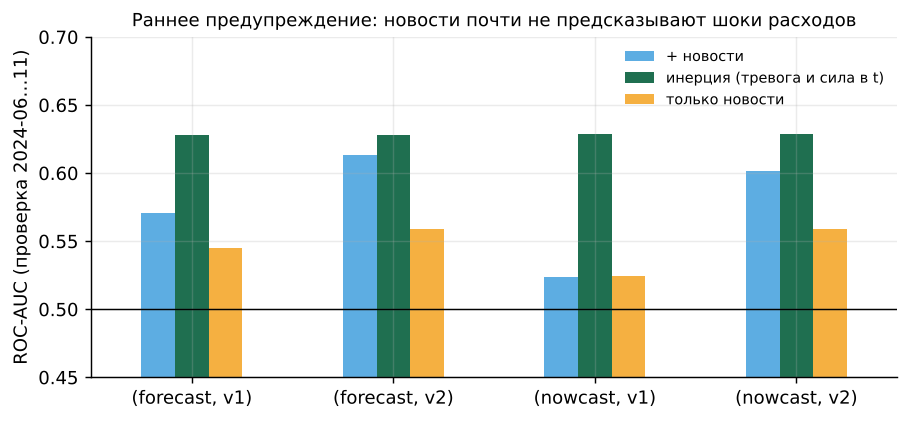

Раннее предупреждение

Результат отрицательный. Лучший сигнал даёт инерция: если шок был в месяце t, он вероятен и в t+1 (lift 3,0 в верхних 5 % прогнозов). Новости версии 2 сами по себе дают ROC-AUC 0,56. Вместе с инерцией ROC-AUC почти не меняется (0,60-0,64 против 0,63), а lift в верхних 5 % снижается (2,2-2,4 против 3,0). Типичные происшествия (пожары, атаки БПЛА, аварии) не сдвигают среднедушевые безналичные расходы МО. Связь между тяжёлым происшествием в МО и тревогой в расходах по квартилям населения даёт lift от 0,94 до 1,26, то есть около единицы (`results/news_severe_incident_lift.csv`). Следовательно, шоки в расходах заранее почти непредсказуемы, а раннее обнаружение достигается иначе: детектор срабатывает в первый же месяц шока (у BOCPD задержка 0,1 мес.), а новости поступают ежедневно, раньше месячных данных о расходах, и помогают объяснить тревогу.

# 6. Новости и их согласование с данными СберИндекса

## 6.1 Источники и объём

Используются Telegram-каналы ТАСС (185 763 сообщения), РИА Новости (126 260), Интерфакс (31 434) и МЧС России (12 294) за период с января 2022 г. по декабрь 2024 г., всего 356 тыс. сообщений (экспорт Telegram Desktop). Сначала применяется широкий словарный фильтр (`configs/news_llm.yaml`, параметр `prefilter`) со словами «паводок», «пожар», «БПЛА», «обстрел», «отключение», «авария» и т. п. Он отсекает спорт, политику и рекламу, чтобы не расходовать на них вычисления на GPU. После фильтра в языковую модель поступает около трети сообщений: например, у ТАСС около 55 тыс. из 186 тыс., у Интерфакса 9,1 тыс. из 31 тыс.

## 6.2 Версия 1: правила, Natasha и словарь

Первая версия определяла тип события по словарю, извлекала места с помощью NER-модели Natasha с морфологическим анализом и привязывала их через газеттир. Газеттир включал 144 названия регионов, 12 582 варианта названий МО и 129 тыс. населённых пунктов ИНИД, привязанных к МО по полигонам справочника СберИндекса. Проверка 200 случайных событий показала: место верно в 80,9 % случаев, тип в 79,0 %, оба поля в 69,3 %.

Типичные ошибки: имена людей принимались за города («Владимир Путин» привязывался к г. Владимир), в выборку попадали дайджесты, сообщения о предотвращённых терактах, судебные новости, события за пределами России и информационные сообщения МЧС о спасении животных. Версия 1 отклонена, но сохранена в репозитории для сравнения.

## 6.3 Версия 2: классификация языковой моделью и выбор МО из справочника

Используется модель Qwen2.5-7B-Instruct-AWQ (Qwen Team, 2024) в движке vLLM (Kwon и др., 2023) на GPU NVIDIA T4; скорость около 1,4 сообщения в секунду на одну GPU, всего более 20 GPU-часов. Настройки одинаковы для всех каналов: на вход до 1 500 символов, на выход до 300 токенов.

- **Этап A, понимание.** Модель читает сообщение и отвечает в формате JSON по фиксированной схеме: является ли сообщение реальным происшествием, тип (14 типов), тяжесть по шкале от 0 до 3, произошло ли событие в России, места в текстовом виде (населённый пункт, район, город, регион). Инструкция явно исключает дайджесты, судебные новости, предотвращённые теракты, учения, спасение одного человека или животного и т. п.
- **Этап B, привязка к справочнику СберИндекса.** По текстовому описанию места подбираются кандидаты: нечёткое сравнение (rapidfuzz) с названиями МО и населённых пунктов внутри названного региона. Модель выбирает номер кандидата, вариант «только регион» или «не определить». Поэтому итоговый `territory_id` всегда существует в справочнике СберИндекса, и модель не может выдумать МО.
- **Правила согласования.** «Москва», «Санкт-Петербург» и «Севастополь» без указания района относятся к уровню региона: в данных СберИндекса эти города разбиты на внутригородские территории, и приписывание события одной из них было бы ошибкой. Если указан только регион, событие также относится к уровню региона.

## 6.4 От сообщения к признаку «МО × месяц»

1. **Время.** Используется дата публикации по московскому времени. Месяц события совпадает с месяцем публикации, поэтому признак месяца t известен к концу месяца t без использования будущих данных.
2. **Объединение повторов в происшествия.** Сообщения об одном месте и одном типе с интервалом не более 3 дней в пределах одного месяца считаются одним происшествием. Тяжесть происшествия равна максимуму по его сообщениям, громкость равна числу сообщений. Цепочка обрывается на границе месяца: признак месяца t строится только из сообщений месяца t, а длительная ситуация (например, регулярные атаки БПЛА на регион) учитывается в каждом месяце, когда о ней сообщают. Так, 192 сообщения о паводке в Орске объединяются в одно происшествие тяжести 3. В итоге 33 159 сообщений о событиях образуют 11 858 происшествий (сжатие в 2,8 раза).
3. **Признаки «МО × месяц»**: число происшествий по группам (безопасность, бедствия, инфраструктура, прочее), сумма и максимум тяжести, громкость, всплеск относительно среднего за предыдущие 12 месяцев. Аналогичные признаки строятся на уровне региона; в них входят события, привязанные к региону или к любому его МО.
4. **Привязка к МО панели** выполняется по `territory_id` справочника СберИндекса с учётом версий МО 2022-2024 гг. и объединений. События в восьми регионах без данных СберИндекса в панель не попадают, но сохраняются для объяснения.

## 6.5 Точность на проверочной выборке

Эталоном служат 200 случайных сообщений, в которых версия 1 нашла событие. Для 16 строк место и тип проверены мной вручную, остальные 184 строки размечены LLM-ассистентом (Claude) по тем же правилам; на 16 общих строках ручная и автоматическая разметки совпали во всех случаях. Ответ версии 2 по тому же сообщению засчитывается автоматически, если совпадает с верным ответом версии 1. Остальные 56 строк версии 2 размечены по тексту сообщения тем же способом, с комментарием к каждой (`data/validation/news_v2_manual_labels.csv`). Правило строгое: сообщение засчитывается, только если верны все строки версии 2 по нему. Доверительные интервалы долей построены по Уилсону (Wilson, 1927).

| показатель | верно / всего | доля | 95 % ДИ (Уилсон) |
| --- | --- | --- | --- |
| v1: место (все 200) | 161 / 199 | 80,9 % | 74,9 … 85,8 % |
| v1: тип (все 200) | 158 / 200 | 79,0 % | 72,8 … 84,1 % |
| v1: оба (все 200) | 138 / 199 | 69,3 % | 62,6 … 75,3 % |
| v1: место (сообщения, оставленные v2) | 121 / 129 | 93,8 % | 88,2 … 96,8 % |
| v1: тип (сообщения, оставленные v2) | 124 / 130 | 95,4 % | 90,3 … 97,9 % |
| v1: оба (сообщения, оставленные v2) | 116 / 129 | 89,9 % | 83,5 … 94,0 % |
| v2: место | 126 / 130 | 96,9 % | 92,4 … 98,8 % |
| v2: тип (строго) | 121 / 130 | 93,1 % | 87,4 … 96,3 % |
| v2: группа типа (для признаков) | 124 / 130 | 95,4 % | 90,3 … 97,9 % |
| v2: оба (строго) | 118 / 130 | 90,8 % | 84,6 … 94,6 % |
| v2 отбросил «не-события» (тип v1 неверен) | 36 / 42 | 85,7 % | 72,2 … 93,3 % |
| v2 потерял верные события v1 | 22 / 138 | 15,9 % | 10,8 … 23,0 % |

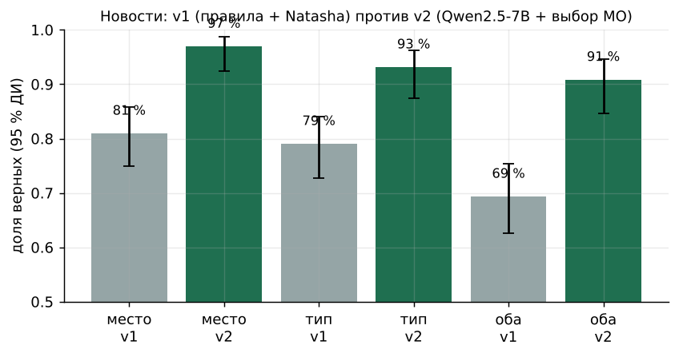

Точность новостей

**Интерпретация.** Основной выигрыш версии 2 связан с фильтром и точностью выдачи. Из 42 сообщений, не описывающих событие (у версии 1 в них неверен тип: дайджесты, суды, спасение животных), версия 2 отбрасывает 86 %. Среди событий, выданных версией 2 по этим 200 сообщениям (130), оба поля верны в 91 % случаев, среди событий версии 1 (200) в 69 %. К конкретному МО версия 2 привязала 55 из 130 сообщений (верно 53), остальные 75 отнесены к уровню региона: в тексте не названо место точнее региона, либо это Москва или Санкт-Петербург без указания района. Если сравнивать версии только на 130 сообщениях, оставленных версией 2 (это более простые сообщения), точность близка: место 93,8 % у версии 1 против 96,9 % у версии 2, тип 95,4 % против 93,1 %, то есть по типу версия 2 здесь даже немного хуже. Цена фильтра: потеря 16 % верных событий версии 1, то есть снижение полноты. Кроме того, проверочная выборка взята из событий версии 1, поэтому точность версии 2 на сообщениях, найденных только ею, этой проверкой не измерена. Для признаков и объяснения тревог важнее точность, поэтому в итоговое решение вошла версия 2.

## 6.6 Использование новостей в итоговом решении

- **Детекция.** Гибрид детектора с тяжёлыми происшествиями (раздел 5.5) добавляет панельному детектору одно событие реестра (4 из 8 вместо 3), BOCPD ни одного. Это наблюдение на 8 событиях, а не доказанный эффект.
- **Объяснение тревог.** К каждой тревоге «МО × месяц» прилагаются происшествия этого МО и региона: тип, тяжесть, число сообщений, каналы. Крупное происшествие найдено у 10 из 2 541 тревог, то есть новости объясняют отдельные крупные шоки, а не большинство тревог.
- **Прогноз.** Новостные признаки не уменьшили MAE (раздел 7.3), поскольку шоки редки и общая ошибка определяется обычными месяцами.
- **Раннее предупреждение.** Новости оказались слабыми предикторами (ROC-AUC 0,56, раздел 5.6).

# 7. Путь решения

В этом разделе описано, какие данные и методы я использовал, что пробовал, какие результаты получил (MAE в скользящем режиме при h = 1 / 3 / 6 / 12) и что вошло в итоговую версию.

## 7.1 Данные

Работа началась с обязательных данных СберИндекса. Сразу стало ясно, что 24 месяцев недостаточно для оценки сезонности, поэтому я добавил национальные ряды СберИндекса с 2018 г. и недельные категории. Затем были добавлены данные Росстата (население, доходы, ИПЦ), ключевая ставка, ERA5 (погода) и Telegram (новости). Каждый источник проверялся: контрольные суммы, сопоставление МО по ОКТМО (2 175 из 2 187 МО панели), выборочная проверка по известным событиям. Найденные дефекты перечислены в разделе 2.2.

## 7.2 Прогноз: последовательность улучшений

| шаг | MAE h=1/3/6/12 | решение и обоснование |
| --- | --- | --- |
| Prophet | 599 / 626 / 735 / 870 | базовая модель |
| наивная модель | 675 / 838 / 1 055 / 1 386 | нижняя граница качества |
| STF (уровень, рост, сезонность по иерархии «категория, регион, МО») | 340 / 477 / 544 / 653 | принят: перенос сезонности даёт основной выигрыш (-43 % к Prophet при h = 1) |
| ансамбль окон роста (3 варианта STF) | 333 / 465 / 532 / 647 | принят: варианты с разными окнами ошибаются по-разному |
| затухающий и региональный рост (9 вариантов STF) | 324 / 446 / 481 / 604 | принят: высокий рост не сохраняется бесконечно (-51 руб. при h = 6 к предыдущему шагу) |
| недельные категории СберИндекса для маркетплейсов, здоровья, транспорта | 319 / 434 / 462 / 524 | принят: у этих категорий нет месячного национального аналога, и рост маркетплейсов (от +50 до +70 %) ранее брался из агрегата «непродовольственные товары» (+15 %) |
| Chronos-2 и TimesFM 2.5 в режиме extended | 317 / 429 / 459 / 476 | принят (финальная модель): -47 руб. при h = 12, -3 руб. при h = 6 |

## 7.3 Отклонённые подходы

Числа взяты из рабочих экспериментов на момент попытки; базовая версия STF тогда могла отличаться от финальной.

- **LightGBM поверх STF** с внешними признаками (новости, погода, ИПЦ, ставка, доходы). Первая версия обучалась на ранних точках и проигрывала из-за сдвига распределения (h = 6: 724). Вторая выучила общие для месяца ошибки (h = 1: 504). Третья, с целевой переменной, очищенной от общего эффекта месяца, дала результат на уровне STF (-3 % при h = 1), но поверх ансамбля с затуханием ухудшила прогноз (342 / 463 / 492 / 605). Подход отклонён: внешние признаки не уменьшают общую MAE, поскольку шоки редки.
- **Собственный тренд МО** по одному году истории: при h = 12 ошибка выросла с 650 до 750. Отклонён, так как по одному году тренд неотличим от шума.
- **Нормировка на число дней в месяце** (високосный февраль 2024 г.): 352 / 500 / 562 / 653, хуже. Отклонена.
- **Медианный уровень вместо среднего**: 362 / 492 / 551 / 662, хуже. Отклонён.
- **Веса ансамбля по прошлым ошибкам** (три лучших члена, веса пропорциональны 1/MAE²): не лучше равных весов. Отклонены.
- **Отказ от затухания для категорий без прямого национального аналога**: лучше при h = 12, хуже при h от 3 до 6. Отклонён. Проверка на 2025 г. показала, что для маркетплейсов затухание действительно оказалось слишком сильным (раздел 4.7).
- **Поправка уровня после тревоги** (частичный откат шока): ошибка рядов с тревогой выросла с 338 до 365. Отклонена: шоки в расходах в среднем устойчивы и ведут себя как сдвиг уровня.
- **Настроенный Prophet** (мультипликативная сезонность, мягкий тренд): хуже Prophet по умолчанию при h = 12 (2 478).
- **Foundation-модели на исходном ряду**: 660 / 898 / 1 301 / 2 805 (Chronos-2), хуже Prophet. Это привело к разработке режимов stf_resid и extended (раздел 4.3).
- **ETS, Theta и ARIMA** на исходном и на очищенном от сезонности ряду приведены в таблицах раздела 4.4. В основном режиме ни одна классическая модель не превосходит ансамбль STF; в узких срезах Theta на очищенном ряду иногда точнее.

## 7.4 Контроль качества и исправленные ошибки

Перед сдачей решение дважды проверено независимым пересчётом. MAE во всех режимах, R², проверка 2025 г., точность новостей и данные лендинга пересчитаны отдельным кодом, не использующим функции проекта, и совпали с результатами. STF дополнительно перезапущена на данных, обрезанных по точке прогноза, и дала идентичный результат, то есть утечки в STF нет. Вторая проверка охватила все компоненты на предмет утечки и все числа в тексте; её замечания учтены в этой версии отчёта.

Проверка выявила одну утечку, в режиме extended у foundation-моделей: сезонный профиль национального ряда для синтетической предыстории вычислялся по всему ряду до августа 2026 г. и без удаления тренда. Я исправил это: профиль теперь строится только по данным до точки прогноза, по остаткам линейного тренда. Chronos-2 и TimesFM 2.5 пересчитаны. Сравнение до и после исправления (MAE, скользящий бэктест):

| модель | версия | MAE h=1 | MAE h=3 | MAE h=6 | MAE h=12 |
| --- | --- | --- | --- | --- | --- |
| Chronos-2, extended | с утечкой (до 08.10) | 340 | 512 | 710 | 969 |
| Chronos-2, extended | исправлено | 332 | 478 | 677 | 960 |
| TimesFM 2.5, extended | с утечкой (до 08.10) | 333 | 485 | 637 | 1 119 |
| TimesFM 2.5, extended | исправлено | 332 | 456 | 548 | 987 |
| Финал: 9 STF + Chronos-2 + TimesFM | с утечкой (до 08.10) | 316 | 430 | 466 | 470 |
| Финал: 9 STF + Chronos-2 + TimesFM | исправлено | 317 | 429 | 459 | 476 |

Шаги «недельные категории» и «режим extended для foundation-моделей» выбраны после анализа ошибок на том же бэктесте, что создаёт риск подгонки под тестовый период. При этом изменения структурные (источник данных, состав категории, способ подачи данных), а числовые параметры не подбирались. Независимой проверкой служит прогноз на 2025 г. (раздел 4.7).

Итоговая копия репозитория прогнана целиком в чистом окружении с версиями библиотек из `requirements.txt` (раздел 9). Все таблицы, прогнозы бэктеста и текст отчёта совпали с исходным расчётом.

## 7.5 Детекция

Сначала все детекторы работали на исходных остатках, и CUSUM и PELT давали F1, близкий к нулю. Анализ выявил три ошибки постановки. (1) В остатках есть общий для страны компонент месяца, поэтому из остатков вычитается медиана категории по месяцу (после этого F1 у CUSUM 0,19, у PELT 0,26). (2) PELT и BinSeg давали бинарную оценку, и порог нельзя было откалибровать; оценка заменена непрерывной (максимальный штраф, при котором точка изменения ещё обнаруживается). (3) На первых месяцах масштаб остатков оценивался как нулевой; введены минимум 4 точки и нижняя граница масштаба. Первая версия сравнения показала лучший результат у панельного детектора: F1 0,64 на полусинтетике, 3 из 8 событий реестра.

Затем я устранил слабые места этого сравнения:

- добавлен классический вариант CUSUM с перезапуском (F1 вырос с 0,19 до 0,52);
- медленные детекторы (BOCPD, PELT, BinSeg) считались на 12 % рядов, теперь на всех;
- на реальных событиях проверялись только 4 детектора, теперь все 14;
- бюджет тревог на уровне МО различался между детекторами, теперь он одинаков и задаётся отдельно в каждом месяце;
- полусинтетика содержала только местные шоки; добавлен сценарий региональных шоков, который выявил слепую зону панельного детектора;
- нормировка в panel_multivariate использовала будущие данные, теперь она причинная.

После этих изменений лучшим по сумме проверок стал BOCPD, а панельный детектор остался лучшим только на местных синтетических шоках (раздел 5.5).

## 7.6 Новости

Версия 1 (правила, Natasha, словарь) на проверке 200 событий дала 69 % событий, верных по обоим полям. Разбор ошибок привёл к версии 2 (языковая модель и выбор МО из справочника). Пробный запуск версии 2 на тех же 200 сообщениях дал 81 % верных выданных событий. Затем исправлены три ошибки: «Москва» при нечётком сравнении попадала в район Москворечье-Сабурово; модель выбирала МО, когда в тексте был назван только регион; некорректно обрабатывались сообщения о режиме воздушной опасности. Полный прогон дал 91 % верных выданных событий (130 событий по 200 сообщениям; версия 1 на тех же 130 сообщениях даёт 90 %, то есть выигрыш обеспечивает фильтр). Объединение повторов в происшествия и оценка тяжести стали признаками версии 2. Вывод: новости помогают объяснить отдельные крупные шоки, но не предсказывают их.

## 7.7 Итоговая конфигурация

[output not shown]

# 8. Интерпретация и ограничения

- Для точного прогноза расходов МО по короткой истории необходимы три элемента: заимствованная сезонность (категории, региона, страны), аккуратная модель роста с затуханием и устойчивость за счёт ансамбля. Сложная индивидуальная модель на 24 точках проигрывает.
- Foundation-модели полезны как члены ансамбля при условии подготовки данных. Применённые к исходному короткому ряду, они уступают Prophet.
- Шоки в среднедушевых безналичных расходах МО редки и в основном происходят в небольших МО. События в крупных городах растворяются в среднем по городу.

**Ограничения:**

- нет данных по восьми приграничным регионам;
- бэктест охватывает только 2024 г., при h = 12 доступна одна точка прогноза;
- на уровне МО прогноз 2025 г. проверен только в агрегате;
- эталонные метки новостей в проверочной выборке в основном поставлены LLM-ассистентом, согласие с ручной разметкой проверено на 16 строках;
- полнота версии 2 составляет 84 % относительно верных событий версии 1;
- интервалы прогноза при h ≥ 3 узковаты;
- при общем пороге тревоги детектора концентрируются в январе, поэтому рекомендуется порог по месяцу (раздел 5.4);
- реальных событий для проверки детекторов мало (8 и 49), различия между лучшими детекторами на них статистически не значимы;
- в анализе раннего предупреждения и ошибок в месяцы шоков шок определён панельным детектором (местный шок);
- классические модели и foundation-модели в режимах raw и stf_resid рассчитаны без недельных категорий.

# 9. Воспроизводимость

```bash
pip install -r requirements.txt   # Python 3.12 или 3.13
bash run_all.sh                   # все таблицы, графики, лендинг и отчёт без GPU, около 1-1,5 ч на 2 ядрах
FULL=1 bash run_all.sh            # дополнительно пересчитать шаги, которым нужен GPU
```

- **Окружение.** Python 3.12 или 3.13. В `requirements.txt` закреплены точные версии всех пакетов, включая зависимости, на которых получены результаты. Для пересчёта Prophet и foundation-моделей нужны пакеты из `requirements-gpu.txt`. Разметка новостей языковой моделью выполняется в отдельном окружении из `requirements-llm.txt`, поскольку vllm 0.31 несовместим с версией numpy основного расчёта.
- **Конфигурации:** `configs/models.yaml` (STF, ансамбль, Prophet, LightGBM), `configs/changepoint.yaml` (детекторы, полусинтетика), `configs/news_llm.yaml` (языковая модель, фильтр).
- **Долгие шаги** (Prophet, foundation-модели, ARIMA, разметка новостей) по умолчанию не перезапускаются: их результаты хранятся в `results/` и `data/processed/llm_full/`, поэтому `run_all.sh` без GPU воспроизводит все таблицы отчёта. Режим `FULL=1` пересчитывает и их.
- **Случайность** зафиксирована: полусинтетика seed 7, бутстреп seed 0, LightGBM seed 0.
- **Отчёт** пересобирается командой `python scripts/render_report.py`, таблицы берутся из `results/*.csv`.
- **Проверка.** Публичная копия репозитория прогнана целиком в чистом окружении с версиями из `requirements.txt`: все таблицы `results/*.csv`, прогнозы бэктеста и текст отчёта совпали с исходным расчётом.

# Литература

1. Adams R. P., MacKay D. J. C. Bayesian online changepoint detection. arXiv:0710.3742, 2007.
2. Ansari A. F. et al. Chronos-2: from univariate to universal forecasting. arXiv, 2025.
3. Assimakopoulos V., Nikolopoulos K. The theta model: a decomposition approach to forecasting. International Journal of Forecasting, 2000, 16(4), 521-530.
4. Cameron A. C., Gelbach J. B., Miller D. L. Bootstrap-based improvements for inference with clustered errors. Review of Economics and Statistics, 2008, 90(3), 414-427.
5. Das A., Kong W., Sen R., Zhou Y. A decoder-only foundation model for time-series forecasting. ICML, 2024.
6. Gardner E. S., McKenzie E. Forecasting trends in time series. Management Science, 1985, 31(10), 1237-1246.
7. Hersbach H. et al. The ERA5 global reanalysis. Quarterly Journal of the Royal Meteorological Society, 2020, 146(730), 1999-2049.
8. Hyndman R. J., Khandakar Y. Automatic time series forecasting: the forecast package for R. Journal of Statistical Software, 2008, 27(3).
9. Hyndman R. J., Koehler A. B. Another look at measures of forecast accuracy. International Journal of Forecasting, 2006, 22(4), 679-688.
10. Hyndman R. J., Koehler A. B., Ord J. K., Snyder R. D. Forecasting with exponential smoothing: the state space approach. Springer, 2008.
11. Killick R., Fearnhead P., Eckley I. A. Optimal detection of changepoints with a linear computational cost. Journal of the American Statistical Association, 2012, 107(500), 1590-1598.
12. Kwon W. et al. Efficient memory management for large language model serving with PagedAttention. SOSP, 2023.
13. Makridakis S., Hibon M. The M3-Competition: results, conclusions and implications. International Journal of Forecasting, 2000, 16(4), 451-476.
14. Page E. S. Continuous inspection schemes. Biometrika, 1954, 41(1/2), 100-115.
15. Qwen Team. Qwen2.5 technical report. arXiv:2412.15115, 2024.
16. Smith J., Wallis K. F. A simple explanation of the forecast combination puzzle. Oxford Bulletin of Economics and Statistics, 2009, 71(3), 331-355.
17. Taylor S. J., Letham B. Forecasting at scale. The American Statistician, 2018, 72(1), 37-45.
18. Truong C., Oudre L., Vayatis N. Selective review of offline change point detection methods. Signal Processing, 2020, 167, 107299.
19. Wilson E. B. Probable inference, the law of succession, and statistical inference. Journal of the American Statistical Association, 1927, 22(158), 209-212.